# ANCOVA in Reading Words (1 Min) (Reading Words (1 Min))

Geiser C. Challco geiser@alumni.usp.br

- Setting Initial Variables
- Descriptive Statistics of Initial Data
- ANCOVA and Pairwise for one factor: **grupo**
  - Without remove non-normal data
  - Computing ANCOVA and PairWise After removing non-normal data (OK)
    - Plots for ancova
    - Checking linearity assumption
    - Checking normality and homogeneity
- ANCOVA and Pairwise for two factors **grupo:Sexo**
  - Without remove non-normal data
  - Computing ANCOVA and PairWise After removing non-normal data (OK)
    - Plots for ancova
    - Checking linearity assumption
    - Checking normality and homogeneity
- ANCOVA and Pairwise for two factors **grupo:Zona**
  - Without remove non-normal data
  - Computing ANCOVA and PairWise After removing non-normal data (OK)
    - Plots for ancova
    - Checking linearity assumption
    - Checking normality and homogeneity
- ANCOVA and Pairwise for two factors **grupo:Cor.Raca**
  - Without remove non-normal data
  - Computing ANCOVA and PairWise After removing non-normal data (OK)
    - Plots for ancova
    - Checking linearity assumption
    - Checking normality and homogeneity
- ANCOVA and Pairwise for two factors **grupo:Serie**
  - Without remove non-normal data
  - Computing ANCOVA and PairWise After removing non-normal data (OK)
    - Plots for ancova
    - Checking linearity assumption
    - Checking normality and homogeneity
- ANCOVA and Pairwise for two factors **grupo:TFL.lidas.per.min.quintile**
  - Without remove non-normal data
  - Computing ANCOVA and PairWise After removing non-normal data (OK)
    - Plots for ancova
    - Checking linearity assumption
    - Checking normality and homogeneity
- Summary of Results
  - Descriptive Statistics
  - ANCOVA Table Comparison
  - PairWise Table Comparison
  - EMMS Table Comparison

**NOTE**:

- Teste ANCOVA para determinar se houve diferenças significativas no Reading Words (1 Min) (medido usando pre- e pos-testes).
- ANCOVA test to determine whether there were significant differences in Reading Words (1 Min) (measured using pre- and post-tests).

# Setting Initial Variables

```r
dv = "TFL.lidas.per.min"
dv.pos = "TFL.lidas.per.min.pos"
dv.pre = "TFL.lidas.per.min.pre"

fatores2 <- c("Sexo","Zona","Cor.Raca","Serie","TFL.lidas.per.min.quintile")
lfatores2 <- as.list(fatores2)
names(lfatores2) <- fatores2

fatores1 <- c("grupo", fatores2)
lfatores1 <- as.list(fatores1)
names(lfatores1) <- fatores1

lfatores <- c(lfatores1)

color <- list()
color[["prepost"]] = c("#ffee65","#f28e2B")
color[["grupo"]] = c("#bcbd22","#fd7f6f")
color[["Sexo"]] = c("#FF007F","#4D4DFF")
color[["Zona"]] = c("#AA00FF","#00CCCC")
color[["Cor.Raca"]] = c(
  "Parda"="#b97100","Indígena"="#9F262F",
  "Branca"="#87c498", "Preta"="#848283","Amarela"="#D6B91C"
)

level <- list()
level[["grupo"]] = c("Controle","Experimental")
level[["Sexo"]] = c("F","M")
level[["Zona"]] = c("Rural","Urbana")
level[["Cor.Raca"]] = c("Parda","Indígena","Branca", "Preta","Amarela")
level[["Serie"]] = c("6 ano","7 ano","8 ano","9 ano")

# ..

ymin <- 0
ymax <- 0

ymin.ci <- 0
ymax.ci <- 0


color[["grupo:Sexo"]] = c(
  "Controle:F"="#ff99cb", "Controle:M"="#b7b7ff",
  "Experimental:F"="#FF007F", "Experimental:M"="#4D4DFF",
  "Controle.F"="#ff99cb", "Controle.M"="#b7b7ff",
  "Experimental.F"="#FF007F", "Experimental.M"="#4D4DFF"
)
color[["grupo:Zona"]] = c(
  "Controle:Rural"="#b2efef","Controle:Urbana"="#e5b2ff",
  "Experimental:Rural"="#00CCCC", "Experimental:Urbana"="#AA00FF",
  "Controle.Rural"="#b2efef","Controle.Urbana"="#e5b2ff",
  "Experimental.Rural"="#00CCCC", "Experimental.Urbana"="#AA00FF"
)
color[["grupo:Cor.Raca"]] = c(
    "Controle:Parda"="#e3c699", "Experimental:Parda"="#b97100",
    "Controle:Indígena"="#e2bdc0", "Experimental:Indígena"="#9F262F",
    "Controle:Branca"="#c0e8cb", "Experimental:Branca"="#87c498",
    "Controle:Preta"="#dad9d9", "Experimental:Preta"="#848283",
    "Controle:Amarela"="#eee3a4", "Experimental:Amarela"="#D6B91C",

    "Controle.Parda"="#e3c699", "Experimental.Parda"="#b97100",
    "Controle.Indígena"="#e2bdc0", "Experimental.Indígena"="#9F262F",
    "Controle.Branca"="#c0e8cb", "Experimental.Branca"="#87c498",
    "Controle.Preta"="#dad9d9", "Experimental.Preta"="#848283",
    "Controle.Amarela"="#eee3a4", "Experimental.Amarela"="#D6B91C"
)


for (coln in c("vocab","vocab.teach","vocab.non.teach","score.tde",
               "TFL.lidas.per.min","TFL.corretas.per.min","TFL.erradas.per.min","TFL.omitidas.per.min",
               "leitura.compreensao")) {
  color[[paste0(coln,".quintile")]] = c("#BF0040","#FF0000","#800080","#0000FF","#4000BF")
  level[[paste0(coln,".quintile")]] = c("1st quintile","2nd quintile","3rd quintile","4th quintile","5th quintile")
  color[[paste0("grupo:",coln,".quintile")]] = c(
    "Experimental.1st quintile"="#BF0040", "Controle.1st quintile"="#d8668c",
    "Experimental.2nd quintile"="#FF0000", "Controle.2nd quintile"="#ff7f7f",
    "Experimental.3rd quintile"="#8fce00", "Controle.3rd quintile"="#ddf0b2",
    "Experimental.4th quintile"="#0000FF", "Controle.4th quintile"="#b2b2ff",
    "Experimental.5th quintile"="#4000BF", "Controle.5th quintile"="#b299e5",

    "Experimental:1st quintile"="#BF0040", "Controle:1st quintile"="#d8668c",
    "Experimental:2nd quintile"="#FF0000", "Controle:2nd quintile"="#ff7f7f",
    "Experimental:3rd quintile"="#8fce00", "Controle:3rd quintile"="#ddf0b2",
    "Experimental:4th quintile"="#0000FF", "Controle:4th quintile"="#b2b2ff",
    "Experimental:5th quintile"="#4000BF", "Controle:5th quintile"="#b299e5")
}


gdat <- read_excel("../data/data.xlsx", sheet = "sumary")
gdat <- gdat[which(is.na(gdat$Necessidade.Deficiencia) & !is.na(gdat$Stari.Grupo)),]



dat <- gdat
dat$grupo <- factor(dat[["Stari.Grupo"]], level[["grupo"]])
for (coln in c(names(lfatores))) {
  dat[[coln]] <- factor(dat[[coln]], level[[coln]][level[[coln]] %in% unique(dat[[coln]])])
}
dat <- dat[which(!is.na(dat[[dv.pre]]) & !is.na(dat[[dv.pos]])),]
dat <- dat[,c("id",names(lfatores),dv.pre,dv.pos)]

dat.long <- rbind(dat, dat)
dat.long$time <- c(rep("pre", nrow(dat)), rep("pos", nrow(dat)))
dat.long$time <- factor(dat.long$time, c("pre","pos"))
dat.long[[dv]] <- c(dat[[dv.pre]], dat[[dv.pos]])


for (f in c("grupo", names(lfatores))) {
  if (is.null(color[[f]]) && length(unique(dat[[f]])) > 0)
      color[[f]] <- distinctColorPalette(length(unique(dat[[f]])))
}
for (f in c(fatores2)) {
  if (is.null(color[[paste0("grupo:",f)]]) && length(unique(dat[[f]])) > 0)
    color[[paste0("grupo:",f)]] <- distinctColorPalette(length(unique(dat[["grupo"]]))*length(unique(dat[[f]])))
}

ldat <- list()
laov <- list()
lpwc <- list()
lemms <- list()
```

# Descriptive Statistics of Initial Data

```r
df <- get.descriptives(dat, c(dv.pre, dv.pos), c("grupo"),
                       include.global = T, symmetry.test = T, normality.test = F)
df <- plyr::rbind.fill(
  df, do.call(plyr::rbind.fill, lapply(lfatores2, FUN = function(f) {
    if (nrow(dat) > 0 && sum(!is.na(unique(dat[[f]]))) > 1)
      get.descriptives(dat, c(dv.pre,dv.pos), c("grupo", f),
                       symmetry.test = T, normality.test = F)
    }))
)
df <- df[,c(fatores1[fatores1 %in% colnames(df)],"variable",
            colnames(df)[!colnames(df) %in% c(fatores1,"variable")])]
```

| grupo | Sexo | Zona | Cor.Raca | Serie | TFL.lidas.per.min.quintile | variable | n | mean | median | min | max | sd | se | ci | iqr | symmetry | skewness | kurtosis |
| --- | --- | --- | --- | --- | --- | --- | --- | --- | --- | --- | --- | --- | --- | --- | --- | --- | --- | --- |
| Controle |  |  |  |  |  | TFL.lidas.per.min.pre | 91 | 91.923 | 94.0 | 27 | 154 | 24.115 | 2.528 | 5.022 | 30.50 | YES | -0.184 | -0.128 |
| Experimental |  |  |  |  |  | TFL.lidas.per.min.pre | 53 | 93.528 | 95.0 | 54 | 135 | 19.277 | 2.648 | 5.313 | 27.00 | YES | -0.069 | -0.471 |
|  |  |  |  |  |  | TFL.lidas.per.min.pre | 144 | 92.514 | 95.0 | 27 | 154 | 22.399 | 1.867 | 3.690 | 29.00 | YES | -0.183 | -0.033 |
| Controle |  |  |  |  |  | TFL.lidas.per.min.pos | 91 | 113.593 | 114.0 | 43 | 187 | 28.508 | 2.988 | 5.937 | 44.00 | YES | 0.253 | -0.327 |
| Experimental |  |  |  |  |  | TFL.lidas.per.min.pos | 53 | 114.774 | 112.0 | 67 | 195 | 27.425 | 3.767 | 7.559 | 40.00 | NO | 0.701 | 0.273 |
|  |  |  |  |  |  | TFL.lidas.per.min.pos | 144 | 114.028 | 112.0 | 43 | 195 | 28.024 | 2.335 | 4.616 | 42.00 | YES | 0.408 | -0.068 |
| Controle | F |  |  |  |  | TFL.lidas.per.min.pre | 36 | 93.917 | 96.5 | 40 | 154 | 24.110 | 4.018 | 8.158 | 23.75 | YES | -0.129 | 0.165 |
| Controle | M |  |  |  |  | TFL.lidas.per.min.pre | 55 | 90.618 | 92.0 | 27 | 141 | 24.250 | 3.270 | 6.556 | 33.50 | YES | -0.214 | -0.440 |
| Experimental | F |  |  |  |  | TFL.lidas.per.min.pre | 22 | 98.455 | 96.5 | 60 | 135 | 17.470 | 3.725 | 7.746 | 22.25 | YES | -0.190 | -0.260 |
| Experimental | M |  |  |  |  | TFL.lidas.per.min.pre | 31 | 90.032 | 90.0 | 54 | 135 | 20.001 | 3.592 | 7.336 | 19.50 | YES | 0.105 | -0.607 |
| Controle | F |  |  |  |  | TFL.lidas.per.min.pos | 36 | 121.194 | 118.5 | 87 | 187 | 26.148 | 4.358 | 8.847 | 37.00 | NO | 0.615 | -0.443 |
| Controle | M |  |  |  |  | TFL.lidas.per.min.pos | 55 | 108.618 | 108.0 | 43 | 176 | 29.114 | 3.926 | 7.871 | 42.00 | YES | 0.196 | -0.580 |
| Experimental | F |  |  |  |  | TFL.lidas.per.min.pos | 22 | 125.318 | 117.5 | 82 | 195 | 26.032 | 5.550 | 11.542 | 38.75 | NO | 0.587 | 0.116 |
| Experimental | M |  |  |  |  | TFL.lidas.per.min.pos | 31 | 107.290 | 101.0 | 67 | 184 | 26.267 | 4.718 | 9.635 | 26.00 | NO | 0.962 | 0.822 |
| Controle |  | Rural |  |  |  | TFL.lidas.per.min.pre | 58 | 91.914 | 94.5 | 27 | 154 | 26.233 | 3.445 | 6.898 | 38.25 | YES | -0.189 | -0.347 |
| Controle |  | Urbana |  |  |  | TFL.lidas.per.min.pre | 7 | 93.000 | 99.0 | 48 | 124 | 24.055 | 9.092 | 22.248 | 19.00 | NO | -0.586 | -0.815 |
| Controle |  |  |  |  |  | TFL.lidas.per.min.pre | 26 | 91.654 | 92.0 | 54 | 139 | 19.626 | 3.849 | 7.927 | 22.25 | YES | 0.088 | -0.247 |
| Experimental |  | Rural |  |  |  | TFL.lidas.per.min.pre | 35 | 90.714 | 90.0 | 54 | 135 | 18.909 | 3.196 | 6.496 | 19.00 | YES | 0.062 | -0.526 |
| Experimental |  | Urbana |  |  |  | TFL.lidas.per.min.pre | 6 | 102.667 | 95.5 | 90 | 135 | 17.455 | 7.126 | 18.318 | 15.25 | NO | 0.921 | -0.930 |
| Experimental |  |  |  |  |  | TFL.lidas.per.min.pre | 12 | 97.167 | 98.5 | 54 | 117 | 20.683 | 5.971 | 13.141 | 32.00 | NO | -0.611 | -0.922 |
| Controle |  | Rural |  |  |  | TFL.lidas.per.min.pos | 58 | 106.276 | 105.5 | 43 | 187 | 25.144 | 3.302 | 6.611 | 31.50 | YES | 0.330 | 0.649 |
| Controle |  | Urbana |  |  |  | TFL.lidas.per.min.pos | 7 | 142.857 | 150.0 | 88 | 176 | 28.399 | 10.734 | 26.264 | 23.00 | NO | -0.735 | -0.690 |
| Controle |  |  |  |  |  | TFL.lidas.per.min.pos | 26 | 122.038 | 128.0 | 68 | 176 | 29.198 | 5.726 | 11.793 | 42.25 | YES | 0.007 | -1.036 |
| Experimental |  | Rural |  |  |  | TFL.lidas.per.min.pos | 35 | 109.371 | 105.0 | 70 | 184 | 23.204 | 3.922 | 7.971 | 22.50 | NO | 1.008 | 1.248 |
| Experimental |  | Urbana |  |  |  | TFL.lidas.per.min.pos | 6 | 134.333 | 123.0 | 99 | 195 | 34.541 | 14.101 | 36.248 | 31.00 | NO | 0.685 | -1.190 |
| Experimental |  |  |  |  |  | TFL.lidas.per.min.pos | 12 | 120.750 | 133.0 | 67 | 166 | 31.758 | 9.168 | 20.178 | 48.75 | YES | -0.359 | -1.448 |
| Controle |  |  | Parda |  |  | TFL.lidas.per.min.pre | 42 | 92.381 | 95.0 | 27 | 135 | 23.486 | 3.624 | 7.319 | 33.00 | NO | -0.511 | -0.178 |
| Controle |  |  | Indígena |  |  | TFL.lidas.per.min.pre | 3 | 117.000 | 101.0 | 96 | 154 | 32.140 | 18.556 | 79.841 | 29.00 | few data | 0.000 | 0.000 |
| Controle |  |  | Branca |  |  | TFL.lidas.per.min.pre | 12 | 105.500 | 103.5 | 90 | 141 | 15.895 | 4.588 | 10.099 | 25.00 | NO | 0.771 | -0.536 |
| Controle |  |  | Preta |  |  | TFL.lidas.per.min.pre | 1 | 99.000 | 99.0 | 99 | 99 |  |  |  | 0.00 | few data | 0.000 | 0.000 |

[output cut: 52 more lines]

# ANCOVA and Pairwise for one factor: **grupo**

## Without remove non-normal data

```r
pdat = remove_group_data(dat[!is.na(dat[["grupo"]]),], "TFL.lidas.per.min.pos", "grupo")

pdat.long <- rbind(pdat[,c("id","grupo")], pdat[,c("id","grupo")])
pdat.long[["time"]] <- c(rep("pre", nrow(pdat)), rep("pos", nrow(pdat)))
pdat.long[["time"]] <- factor(pdat.long[["time"]], c("pre","pos"))
pdat.long[["TFL.lidas.per.min"]] <- c(pdat[["TFL.lidas.per.min.pre"]], pdat[["TFL.lidas.per.min.pos"]])

aov = anova_test(pdat, TFL.lidas.per.min.pos ~ TFL.lidas.per.min.pre + grupo)
laov[["grupo"]] <- get_anova_table(aov)
```

```r
pwc <- emmeans_test(pdat, TFL.lidas.per.min.pos ~ grupo, covariate = TFL.lidas.per.min.pre,
                    p.adjust.method = "bonferroni")
```

```r
pwc.long <- emmeans_test(dplyr::group_by_at(pdat.long, "grupo"),
                          TFL.lidas.per.min ~ time,
                          p.adjust.method = "bonferroni")
lpwc[["grupo"]] <- plyr::rbind.fill(pwc, pwc.long)
```

```r
ds <- get.descriptives(pdat, "TFL.lidas.per.min.pos", "grupo", covar = "TFL.lidas.per.min.pre")
ds <- merge(ds[ds$variable != "TFL.lidas.per.min.pre",],
            ds[ds$variable == "TFL.lidas.per.min.pre", !colnames(ds) %in% c("variable")],
            by = "grupo", all.x = T, suffixes = c("", ".TFL.lidas.per.min.pre"))
ds <- merge(get_emmeans(pwc), ds, by = "grupo", suffixes = c(".emms", ""))
ds <- ds[,c("grupo","n","mean.TFL.lidas.per.min.pre","se.TFL.lidas.per.min.pre","mean","se",
            "emmean","se.emms","conf.low","conf.high")]

colnames(ds) <- c("grupo", "N", paste0(c("M","SE")," (pre)"),
                  paste0(c("M","SE"), " (unadj)"),
                  paste0(c("M", "SE"), " (adj)"), "conf.low", "conf.high")

lemms[["grupo"]] <- ds
```

## Computing ANCOVA and PairWise After removing non-normal data (OK)

```r
wdat = pdat

res = residuals(lm(TFL.lidas.per.min.pos ~ TFL.lidas.per.min.pre + grupo, data = wdat))
non.normal = getNonNormal(res, wdat$id, plimit = 0.05)

wdat = wdat[!wdat$id %in% non.normal,]

wdat.long <- rbind(wdat[,c("id","grupo")], wdat[,c("id","grupo")])
wdat.long[["time"]] <- c(rep("pre", nrow(wdat)), rep("pos", nrow(wdat)))
wdat.long[["time"]] <- factor(wdat.long[["time"]], c("pre","pos"))
wdat.long[["TFL.lidas.per.min"]] <- c(wdat[["TFL.lidas.per.min.pre"]], wdat[["TFL.lidas.per.min.pos"]])

ldat[["grupo"]] = wdat

(non.normal)
```

```
##  [1] "P463"  "P956"  "P3498" "P3609" "P3721" "P3516" "P808"  "P445"  "P3521" "P3504" "P1010"
## [12] "P3729" "P446"  "P1109" "P465"  "P3492" "P942"  "P3581" "P1091" "P820"  "P1094" "P3627"
## [23] "P621"  "P3566" "P184"  "P133"  "P628"  "P3501" "P816"  "P1017" "P950"  "P947"  "P1097"
## [34] "P3495" "P3615" "P1716" "P3505" "P3512" "P3524" "P3565" "P3502" "P128"  "P1089" "P812"
## [45] "P521"  "P448"  "P3558" "P3606" "P3518" "P3624" "P1004" "P994"  "P1000" "P616"  "P618"
## [56] "P829"  "P241"  "P451"  "P515"  "P615"  "P460"  "P813"  "P936"  "P614"  "P457"  "P513"
## [67] "P958"  "P516"  "P1084" "P997"  "P626"  "P3509" "P3734" "P613"  "P3598" "P1107" "P512"
## [78] "P464"  "P625"  "P612"  "P3560" "P3519" "P620"  "P523"  "P948"  "P2210" "P3508" "P943"
## [89] "P3577" "P176"  "P3569" "P1742"
```

```r
aov = anova_test(wdat, TFL.lidas.per.min.pos ~ TFL.lidas.per.min.pre + grupo)
laov[["grupo"]] <- merge(get_anova_table(aov), laov[["grupo"]],
                            by="Effect", suffixes = c("","'"))

(df = get_anova_table(aov))
```

```
## ANOVA Table (type II tests)
##
##                  Effect DFn DFd      F       p p<.05   ges
## 1 TFL.lidas.per.min.pre   1  49 39.759 7.9e-08     * 0.448
## 2                 grupo   1  49  0.929 3.4e-01       0.019
```

| Effect | DFn | DFd | F | p | p<.05 | ges |
| --- | --- | --- | --- | --- | --- | --- |
| TFL.lidas.per.min.pre | 1 | 49 | 39.759 | 0.00 | * | 0.448 |
| grupo | 1 | 49 | 0.929 | 0.34 |  | 0.019 |

```r
pwc <- emmeans_test(wdat, TFL.lidas.per.min.pos ~ grupo, covariate = TFL.lidas.per.min.pre,
                    p.adjust.method = "bonferroni")
```

| term | .y. | group1 | group2 | df | statistic | p | p.adj | p.adj.signif |
| --- | --- | --- | --- | --- | --- | --- | --- | --- |
| TFL.lidas.per.min.pre*grupo | TFL.lidas.per.min.pos | Controle | Experimental | 49 | 0.964 | 0.34 | 0.34 | ns |

```r
pwc.long <- emmeans_test(dplyr::group_by_at(wdat.long, "grupo"),
                         TFL.lidas.per.min ~ time,
                         p.adjust.method = "bonferroni")
lpwc[["grupo"]] <- merge(plyr::rbind.fill(pwc, pwc.long), lpwc[["grupo"]],
                            by=c("grupo","term",".y.","group1","group2"),
                            suffixes = c("","'"))
```

| grupo | term | .y. | group1 | group2 | df | statistic | p | p.adj | p.adj.signif |
| --- | --- | --- | --- | --- | --- | --- | --- | --- | --- |
| Controle | time | TFL.lidas.per.min | pre | pos | 100 | -9.206 | 0 | 0 | **** |
| Experimental | time | TFL.lidas.per.min | pre | pos | 100 | -5.917 | 0 | 0 | **** |

```r
ds <- get.descriptives(wdat, "TFL.lidas.per.min.pos", "grupo", covar = "TFL.lidas.per.min.pre")
ds <- merge(ds[ds$variable != "TFL.lidas.per.min.pre",],
            ds[ds$variable == "TFL.lidas.per.min.pre", !colnames(ds) %in% c("variable")],
            by = "grupo", all.x = T, suffixes = c("", ".TFL.lidas.per.min.pre"))
ds <- merge(get_emmeans(pwc), ds, by = "grupo", suffixes = c(".emms", ""))
ds <- ds[,c("grupo","n","mean.TFL.lidas.per.min.pre","se.TFL.lidas.per.min.pre","mean","se",
            "emmean","se.emms","conf.low","conf.high")]

colnames(ds) <- c("grupo", "N", paste0(c("M","SE")," (pre)"),
                  paste0(c("M","SE"), " (unadj)"),
                  paste0(c("M", "SE"), " (adj)"), "conf.low", "conf.high")

lemms[["grupo"]] <- merge(ds, lemms[["grupo"]], by=c("grupo"), suffixes = c("","'"))
```

| grupo | N | M (pre) | SE (pre) | M (unadj) | SE (unadj) | M (adj) | SE (adj) | conf.low | conf.high |
| --- | --- | --- | --- | --- | --- | --- | --- | --- | --- |
| Controle | 33 | 87.364 | 4.315 | 139.000 | 3.971 | 141.414 | 3.045 | 135.295 | 147.532 |
| Experimental | 19 | 96.947 | 4.019 | 140.684 | 5.427 | 136.492 | 4.036 | 128.382 | 144.602 |

### Plots for ancova

```r
plots <- oneWayAncovaPlots(
  wdat, "TFL.lidas.per.min.pos", "grupo", aov, list("grupo"=pwc), addParam = c("mean_ci"),
  font.label.size=10, step.increase=0.05, p.label="p.adj",
  subtitle = which(aov$Effect == "grupo"))
```

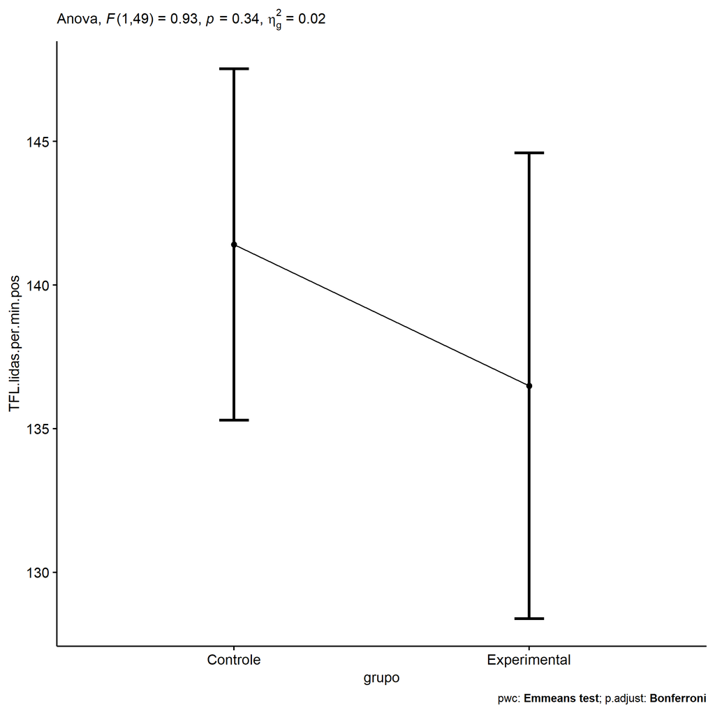

```r
if (!is.null(nrow(plots[["grupo"]]$data)))
  plots[["grupo"]] +
  if (ymin.ci < ymax.ci) ggplot2::ylim(ymin.ci, ymax.ci)
```

```r
plots <- oneWayAncovaBoxPlots(
  wdat, "TFL.lidas.per.min.pos", "grupo", aov, pwc, covar = "TFL.lidas.per.min.pre",
  theme = "classic", color = color[["grupo"]],
  subtitle = which(aov$Effect == "grupo"))
```

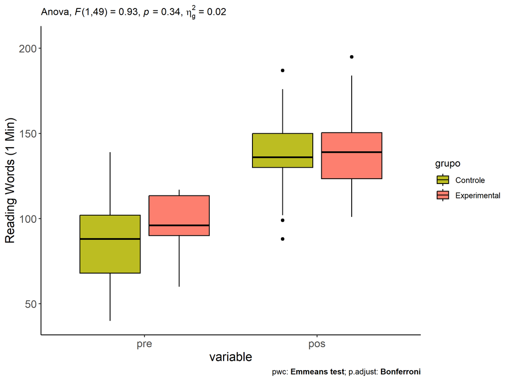

```r
if (length(unique(wdat[["grupo"]])) > 1)
  plots[["grupo"]] + ggplot2::ylab("Reading Words (1 Min)") +
  ggplot2::scale_x_discrete(labels=c('pre', 'pos')) +
  if (ymin < ymax) ggplot2::ylim(ymin, ymax)
```

```r
if (length(unique(wdat.long[["grupo"]])) > 1)
  plots <- oneWayAncovaBoxPlots(
    wdat.long, "TFL.lidas.per.min", "grupo", aov, pwc.long,
    pre.post = "time", theme = "classic", color = color$prepost)
```

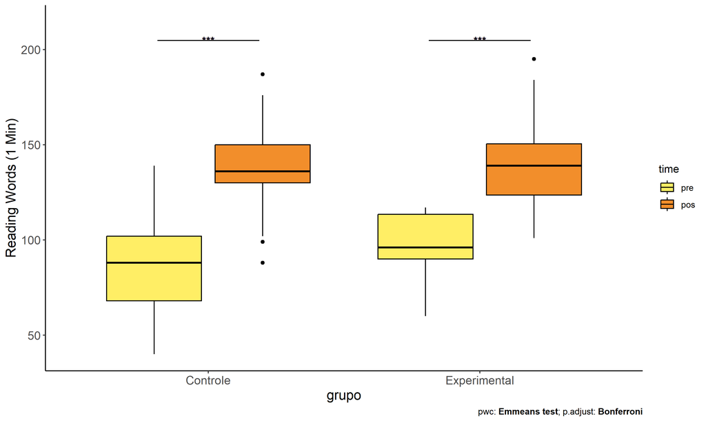

```r
if (length(unique(wdat.long[["grupo"]])) > 1)
  plots[["grupo"]] + ggplot2::ylab("Reading Words (1 Min)") +
  if (ymin < ymax) ggplot2::ylim(ymin, ymax)
```

### Checking linearity assumption

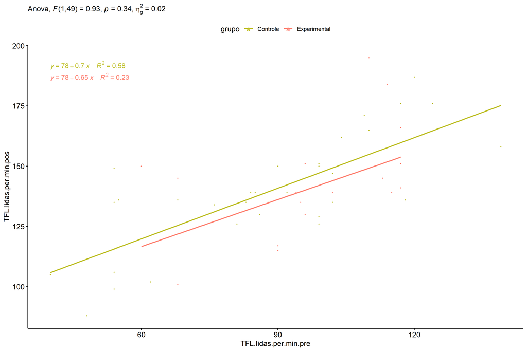

```r
ggscatter(wdat, x = "TFL.lidas.per.min.pre", y = "TFL.lidas.per.min.pos", size = 0.5,
          color = "grupo", add = "reg.line")+
  stat_regline_equation(
    aes(label =  paste(..eq.label.., ..rr.label.., sep = "~~~~"), color = grupo)
  ) +
  ggplot2::labs(subtitle = rstatix::get_test_label(aov, detailed = T, row = which(aov$Effect == "grupo"))) +
  ggplot2::scale_color_manual(values = color[["grupo"]]) +
  if (ymin < ymax) ggplot2::ylim(ymin, ymax)
```

### Checking normality and homogeneity

```r
res <- augment(lm(TFL.lidas.per.min.pos ~ TFL.lidas.per.min.pre + grupo, data = wdat))
```

```r
shapiro_test(res$.resid)
```

```
## # A tibble: 1 × 3
##   variable   statistic p.value
##   <chr>          <dbl>   <dbl>
## 1 res$.resid     0.950  0.0305
```

```r
levene_test(res, .resid ~ grupo)
```

```
## # A tibble: 1 × 4
##     df1   df2 statistic     p
##   <int> <int>     <dbl> <dbl>
## 1     1    50      1.37 0.248
```

# ANCOVA and Pairwise for two factors **grupo:Sexo**

## Without remove non-normal data

```r
pdat = remove_group_data(dat[!is.na(dat[["grupo"]]) & !is.na(dat[["Sexo"]]),],
                         "TFL.lidas.per.min.pos", c("grupo","Sexo"))
pdat = pdat[pdat[["Sexo"]] %in% do.call(
  intersect, lapply(unique(pdat[["grupo"]]), FUN = function(x) {
    unique(pdat[["Sexo"]][which(pdat[["grupo"]] == x)])
  })),]
pdat[["grupo"]] = factor(pdat[["grupo"]], level[["grupo"]])
pdat[["Sexo"]] = factor(
  pdat[["Sexo"]],
  level[["Sexo"]][level[["Sexo"]] %in% unique(pdat[["Sexo"]])])

pdat.long <- rbind(pdat[,c("id","grupo","Sexo")], pdat[,c("id","grupo","Sexo")])
pdat.long[["time"]] <- c(rep("pre", nrow(pdat)), rep("pos", nrow(pdat)))
pdat.long[["time"]] <- factor(pdat.long[["time"]], c("pre","pos"))
pdat.long[["TFL.lidas.per.min"]] <- c(pdat[["TFL.lidas.per.min.pre"]], pdat[["TFL.lidas.per.min.pos"]])

if (length(unique(pdat[["Sexo"]])) >= 2) {
  aov = anova_test(pdat, TFL.lidas.per.min.pos ~ TFL.lidas.per.min.pre + grupo*Sexo)
  laov[["grupo:Sexo"]] <- get_anova_table(aov)
}
```

```r
if (length(unique(pdat[["Sexo"]])) >= 2) {
  pwcs <- list()
  pwcs[["Sexo"]] <- emmeans_test(
    group_by(pdat, grupo), TFL.lidas.per.min.pos ~ Sexo,
    covariate = TFL.lidas.per.min.pre, p.adjust.method = "bonferroni")
  pwcs[["grupo"]] <- emmeans_test(
    group_by(pdat, Sexo), TFL.lidas.per.min.pos ~ grupo,
    covariate = TFL.lidas.per.min.pre, p.adjust.method = "bonferroni")

  pwc <- plyr::rbind.fill(pwcs[["grupo"]], pwcs[["Sexo"]])
  pwc <- pwc[,c("grupo","Sexo", colnames(pwc)[!colnames(pwc) %in% c("grupo","Sexo")])]
}
```

```r
if (length(unique(pdat[["Sexo"]])) >= 2) {
  pwc.long <- emmeans_test(dplyr::group_by_at(pdat.long, c("grupo","Sexo")),
                           TFL.lidas.per.min ~ time,
                           p.adjust.method = "bonferroni")
  lpwc[["grupo:Sexo"]] <- plyr::rbind.fill(pwc, pwc.long)
}
```

```r
if (length(unique(pdat[["Sexo"]])) >= 2) {
  ds <- get.descriptives(pdat, "TFL.lidas.per.min.pos", c("grupo","Sexo"), covar = "TFL.lidas.per.min.pre")
  ds <- merge(ds[ds$variable != "TFL.lidas.per.min.pre",],
              ds[ds$variable == "TFL.lidas.per.min.pre", !colnames(ds) %in% c("variable")],
              by = c("grupo","Sexo"), all.x = T, suffixes = c("", ".TFL.lidas.per.min.pre"))
  ds <- merge(get_emmeans(pwcs[["grupo"]]), ds,
              by = c("grupo","Sexo"), suffixes = c(".emms", ""))
  ds <- ds[,c("grupo","Sexo","n","mean.TFL.lidas.per.min.pre","se.TFL.lidas.per.min.pre","mean","se",
              "emmean","se.emms","conf.low","conf.high")]

  colnames(ds) <- c("grupo","Sexo", "N", paste0(c("M","SE")," (pre)"),
                    paste0(c("M","SE"), " (unadj)"),
                    paste0(c("M", "SE"), " (adj)"), "conf.low", "conf.high")

  lemms[["grupo:Sexo"]] <- ds
}
```

## Computing ANCOVA and PairWise After removing non-normal data (OK)

```r
if (length(unique(pdat[["Sexo"]])) >= 2) {
  wdat = pdat

  res = residuals(lm(TFL.lidas.per.min.pos ~ TFL.lidas.per.min.pre + grupo*Sexo, data = wdat))
  non.normal = getNonNormal(res, wdat$id, plimit = 0.05)

  wdat = wdat[!wdat$id %in% non.normal,]

  wdat.long <- rbind(wdat[,c("id","grupo","Sexo")], wdat[,c("id","grupo","Sexo")])
  wdat.long[["time"]] <- c(rep("pre", nrow(wdat)), rep("pos", nrow(wdat)))
  wdat.long[["time"]] <- factor(wdat.long[["time"]], c("pre","pos"))
  wdat.long[["TFL.lidas.per.min"]] <- c(wdat[["TFL.lidas.per.min.pre"]], wdat[["TFL.lidas.per.min.pos"]])


  ldat[["grupo:Sexo"]] = wdat

  (non.normal)
}
```

```
##  [1] "P1768" "P121"  "P2250" "P2380" "P1743" "P2220" "P2378" "P510"  "P2385" "P2404" "P2214"
## [12] "P2377" "P2294" "P1698" "P945"  "P2209"
```

```r
if (length(unique(pdat[["Sexo"]])) >= 2) {
  aov = anova_test(wdat, TFL.lidas.per.min.pos ~ TFL.lidas.per.min.pre + grupo*Sexo)
  laov[["grupo:Sexo"]] <- merge(get_anova_table(aov), laov[["grupo:Sexo"]],
                                         by="Effect", suffixes = c("","'"))
  df = get_anova_table(aov)
}
```

| Effect | DFn | DFd | F | p | p<.05 | ges |
| --- | --- | --- | --- | --- | --- | --- |
| TFL.lidas.per.min.pre | 1 | 123 | 81.449 | 0.000 | * | 0.398 |
| grupo | 1 | 123 | 0.506 | 0.478 |  | 0.004 |
| Sexo | 1 | 123 | 11.520 | 0.001 | * | 0.086 |
| grupo:Sexo | 1 | 123 | 0.986 | 0.323 |  | 0.008 |

```r
if (length(unique(pdat[["Sexo"]])) >= 2) {
  pwcs <- list()
  pwcs[["Sexo"]] <- emmeans_test(
    group_by(wdat, grupo), TFL.lidas.per.min.pos ~ Sexo,
    covariate = TFL.lidas.per.min.pre, p.adjust.method = "bonferroni")
  pwcs[["grupo"]] <- emmeans_test(
    group_by(wdat, Sexo), TFL.lidas.per.min.pos ~ grupo,
    covariate = TFL.lidas.per.min.pre, p.adjust.method = "bonferroni")

  pwc <- plyr::rbind.fill(pwcs[["grupo"]], pwcs[["Sexo"]])
  pwc <- pwc[,c("grupo","Sexo", colnames(pwc)[!colnames(pwc) %in% c("grupo","Sexo")])]
}
```

| grupo | Sexo | term | .y. | group1 | group2 | df | statistic | p | p.adj | p.adj.signif |
| --- | --- | --- | --- | --- | --- | --- | --- | --- | --- | --- |
|  | F | TFL.lidas.per.min.pre*grupo | TFL.lidas.per.min.pos | Controle | Experimental | 123 | 0.332 | 0.741 | 0.741 | ns |
|  | M | TFL.lidas.per.min.pre*grupo | TFL.lidas.per.min.pos | Controle | Experimental | 123 | -1.177 | 0.241 | 0.241 | ns |
| Controle |  | TFL.lidas.per.min.pre*Sexo | TFL.lidas.per.min.pos | F | M | 123 | 3.299 | 0.001 | 0.001 | ** |
| Experimental |  | TFL.lidas.per.min.pre*Sexo | TFL.lidas.per.min.pos | F | M | 123 | 1.293 | 0.198 | 0.198 | ns |

```r
if (length(unique(pdat[["Sexo"]])) >= 2) {
  pwc.long <- emmeans_test(dplyr::group_by_at(wdat.long, c("grupo","Sexo")),
                           TFL.lidas.per.min ~ time,
                           p.adjust.method = "bonferroni")
  lpwc[["grupo:Sexo"]] <- merge(plyr::rbind.fill(pwc, pwc.long),
                                         lpwc[["grupo:Sexo"]],
                                         by=c("grupo","Sexo","term",".y.","group1","group2"),
                                         suffixes = c("","'"))
}
```

| grupo | Sexo | term | .y. | group1 | group2 | df | statistic | p | p.adj | p.adj.signif |
| --- | --- | --- | --- | --- | --- | --- | --- | --- | --- | --- |
| Controle | F | time | TFL.lidas.per.min | pre | pos | 248 | -4.063 | 0.000 | 0.000 | **** |
| Controle | M | time | TFL.lidas.per.min | pre | pos | 248 | -2.189 | 0.030 | 0.030 | * |
| Experimental | F | time | TFL.lidas.per.min | pre | pos | 248 | -2.483 | 0.014 | 0.014 | * |
| Experimental | M | time | TFL.lidas.per.min | pre | pos | 248 | -2.710 | 0.007 | 0.007 | ** |

```r
if (length(unique(pdat[["Sexo"]])) >= 2) {
  ds <- get.descriptives(wdat, "TFL.lidas.per.min.pos", c("grupo","Sexo"), covar = "TFL.lidas.per.min.pre")
  ds <- merge(ds[ds$variable != "TFL.lidas.per.min.pre",],
              ds[ds$variable == "TFL.lidas.per.min.pre", !colnames(ds) %in% c("variable")],
              by = c("grupo","Sexo"), all.x = T, suffixes = c("", ".TFL.lidas.per.min.pre"))
  ds <- merge(get_emmeans(pwcs[["grupo"]]), ds,
              by = c("grupo","Sexo"), suffixes = c(".emms", ""))
  ds <- ds[,c("grupo","Sexo","n","mean.TFL.lidas.per.min.pre","se.TFL.lidas.per.min.pre",
              "mean","se","emmean","se.emms","conf.low","conf.high")]

  colnames(ds) <- c("grupo","Sexo", "N", paste0(c("M","SE")," (pre)"),
                    paste0(c("M","SE"), " (unadj)"),
                    paste0(c("M", "SE"), " (adj)"), "conf.low", "conf.high")

  lemms[["grupo:Sexo"]] <- merge(ds, lemms[["grupo:Sexo"]],
                                          by=c("grupo","Sexo"), suffixes = c("","'"))
}
```

| grupo | Sexo | N | M (pre) | SE (pre) | M (unadj) | SE (unadj) | M (adj) | SE (adj) | conf.low | conf.high |
| --- | --- | --- | --- | --- | --- | --- | --- | --- | --- | --- |
| Controle | F | 32 | 93.125 | 4.171 | 115.625 | 3.688 | 115.384 | 3.080 | 109.287 | 121.480 |
| Controle | M | 47 | 91.213 | 3.550 | 101.213 | 3.485 | 102.203 | 2.544 | 97.168 | 107.238 |
| Experimental | F | 19 | 101.474 | 3.288 | 119.316 | 4.743 | 113.698 | 4.045 | 105.691 | 121.705 |
| Experimental | M | 30 | 89.233 | 3.621 | 104.733 | 4.099 | 106.998 | 3.191 | 100.682 | 113.314 |

### Plots for ancova

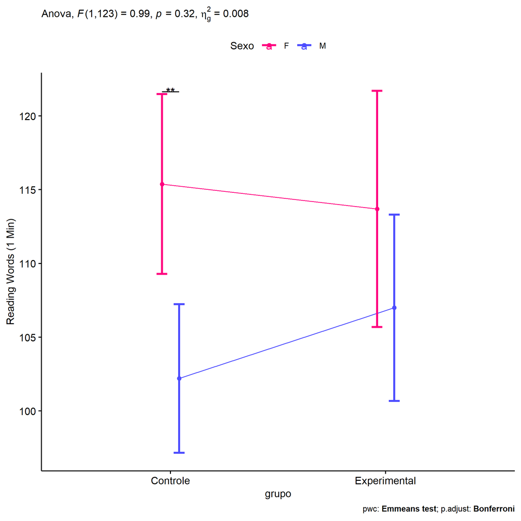

```r
if (length(unique(pdat[["Sexo"]])) >= 2) {
  ggPlotAoC2(pwcs, "grupo", "Sexo", aov, ylab = "Reading Words (1 Min)",
             subtitle = which(aov$Effect == "grupo:Sexo"), addParam = "errorbar") +
    ggplot2::scale_color_manual(values = color[["Sexo"]]) +
    if (ymin.ci < ymax.ci) ggplot2::ylim(ymin.ci, ymax.ci)
}
```

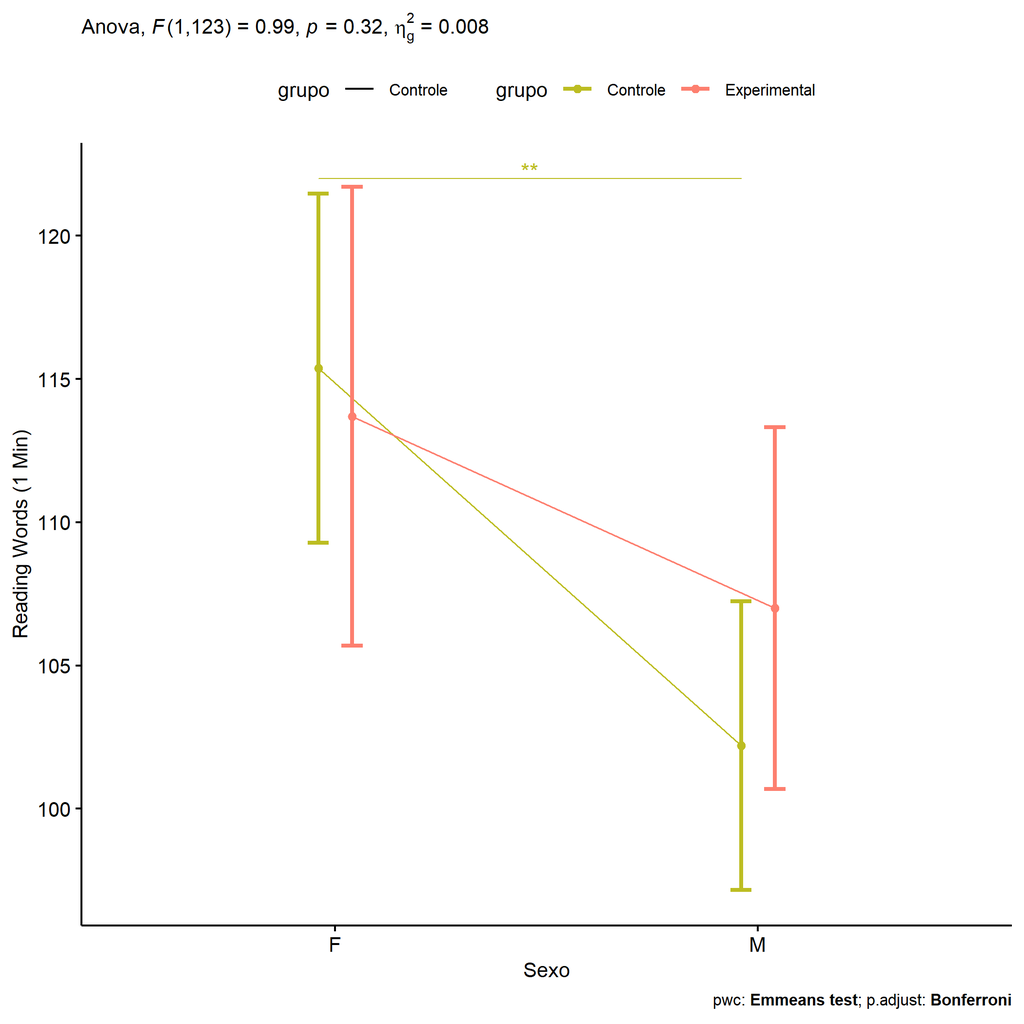

```r
if (length(unique(pdat[["Sexo"]])) >= 2) {
  ggPlotAoC2(pwcs, "Sexo", "grupo", aov, ylab = "Reading Words (1 Min)",
               subtitle = which(aov$Effect == "grupo:Sexo"), addParam = "errorbar") +
      ggplot2::scale_color_manual(values = color[["grupo"]]) +
      if (ymin.ci < ymax.ci) ggplot2::ylim(ymin.ci, ymax.ci)
}
```

```r
if (length(unique(pdat[["Sexo"]])) >= 2) {
  plots <- twoWayAncovaBoxPlots(
    wdat, "TFL.lidas.per.min.pos", c("grupo","Sexo"), aov, pwcs, covar = "TFL.lidas.per.min.pre",
    theme = "classic", color = color[["grupo:Sexo"]],
    subtitle = which(aov$Effect == "grupo:Sexo"))
}
```

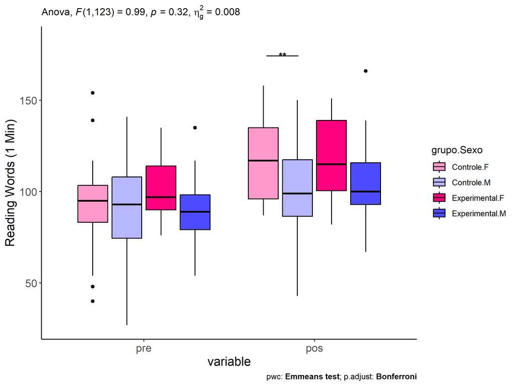

```r
if (length(unique(pdat[["Sexo"]])) >= 2) {
  plots[["grupo:Sexo"]] + ggplot2::ylab("Reading Words (1 Min)") +
  ggplot2::scale_x_discrete(labels=c('pre', 'pos')) +
  if (ymin < ymax) ggplot2::ylim(ymin, ymax)
}
```

```r
if (length(unique(pdat[["Sexo"]])) >= 2) {
  plots <- twoWayAncovaBoxPlots(
    wdat.long, "TFL.lidas.per.min", c("grupo","Sexo"), aov, pwc.long,
    pre.post = "time",
    theme = "classic", color = color$prepost)
}
```

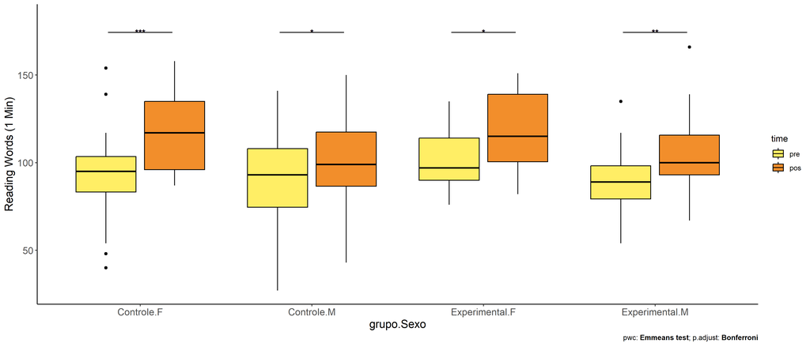

```r
if (length(unique(pdat[["Sexo"]])) >= 2)
  plots[["grupo:Sexo"]] + ggplot2::ylab("Reading Words (1 Min)") +
    if (ymin < ymax) ggplot2::ylim(ymin, ymax)
```

### Checking linearity assumption

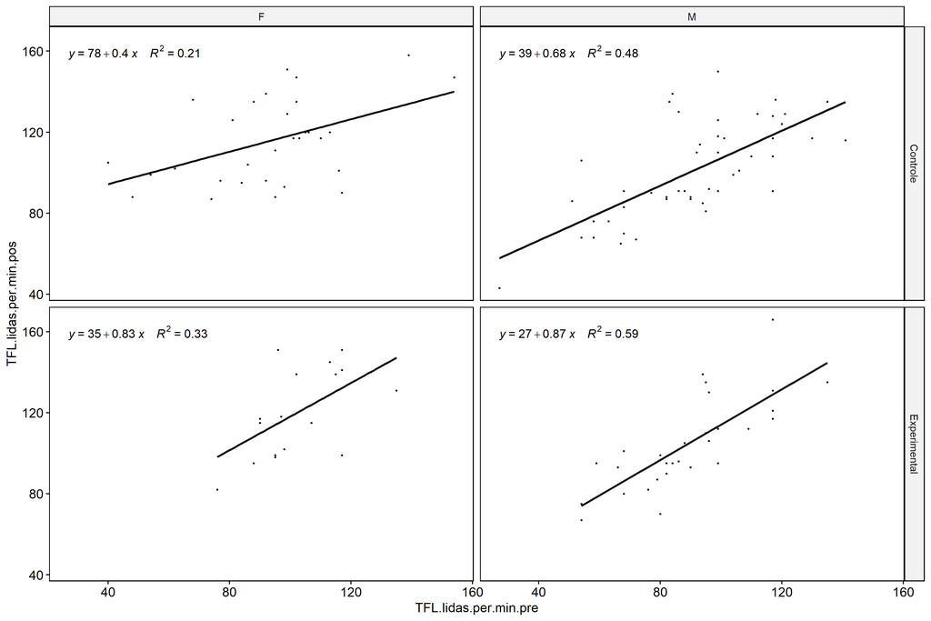

```r
if (length(unique(pdat[["Sexo"]])) >= 2) {
  ggscatter(wdat, x = "TFL.lidas.per.min.pre", y = "TFL.lidas.per.min.pos", size = 0.5,
            facet.by = c("grupo","Sexo"), add = "reg.line")+
    stat_regline_equation(
      aes(label =  paste(..eq.label.., ..rr.label.., sep = "~~~~"))
    ) +
    if (ymin < ymax) ggplot2::ylim(ymin, ymax)
}
```

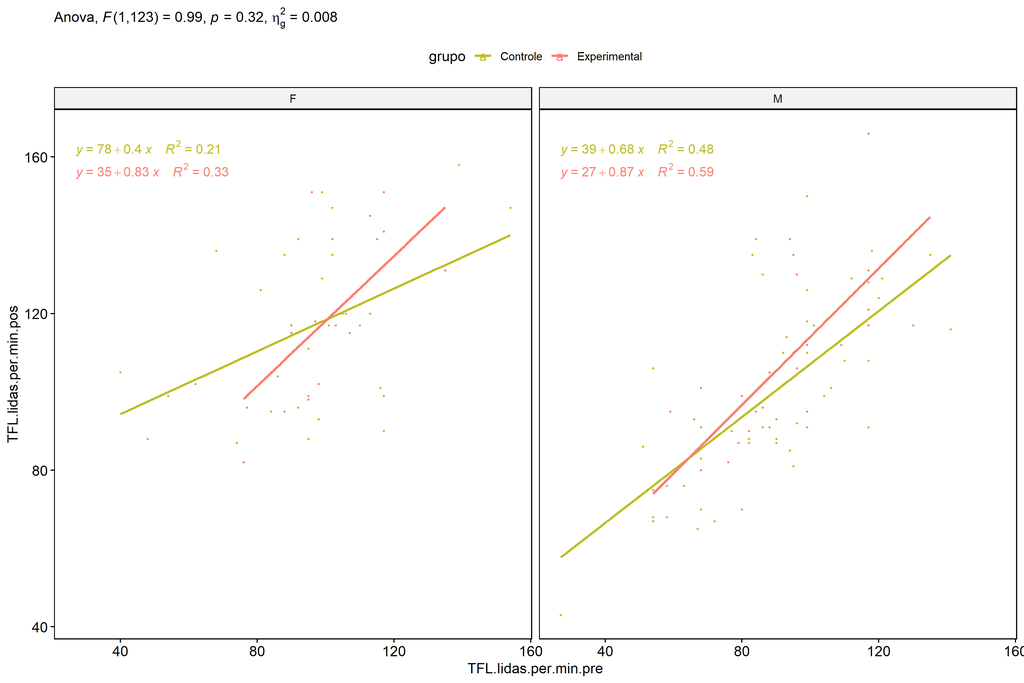

```r
if (length(unique(pdat[["Sexo"]])) >= 2) {
  ggscatter(wdat, x = "TFL.lidas.per.min.pre", y = "TFL.lidas.per.min.pos", size = 0.5,
            color = "grupo", facet.by = "Sexo", add = "reg.line")+
    stat_regline_equation(
      aes(label =  paste(..eq.label.., ..rr.label.., sep = "~~~~"), color = grupo)
    ) +
    ggplot2::labs(subtitle = rstatix::get_test_label(aov, detailed = T, row = which(aov$Effect == "grupo:Sexo"))) +
    ggplot2::scale_color_manual(values = color[["grupo"]]) +
    if (ymin < ymax) ggplot2::ylim(ymin, ymax)
}
```

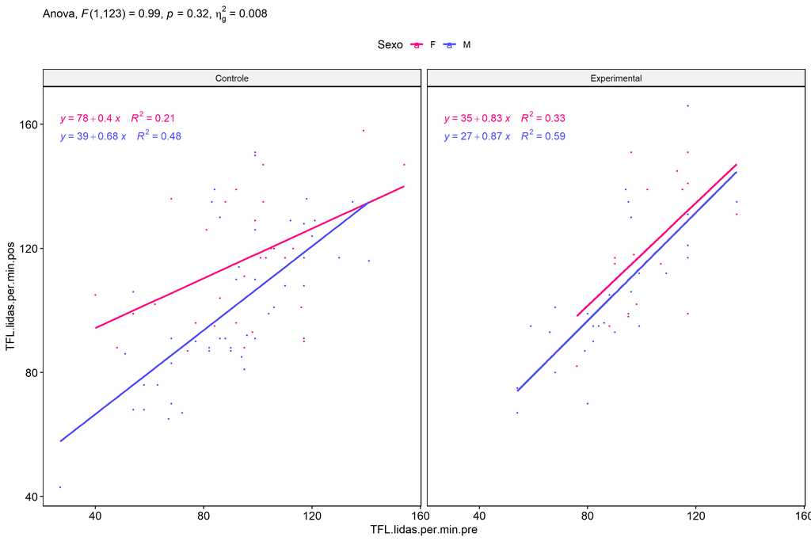

```r
if (length(unique(pdat[["Sexo"]])) >= 2) {
  ggscatter(wdat, x = "TFL.lidas.per.min.pre", y = "TFL.lidas.per.min.pos", size = 0.5,
            color = "Sexo", facet.by = "grupo", add = "reg.line")+
    stat_regline_equation(
      aes(label =  paste(..eq.label.., ..rr.label.., sep = "~~~~"), color = Sexo)
    ) +
    ggplot2::labs(subtitle = rstatix::get_test_label(aov, detailed = T, row = which(aov$Effect == "grupo:Sexo"))) +
    ggplot2::scale_color_manual(values = color[["Sexo"]]) +
    if (ymin < ymax) ggplot2::ylim(ymin, ymax)
}
```

### Checking normality and homogeneity

```r
if (length(unique(pdat[["Sexo"]])) >= 2)
  res <- augment(lm(TFL.lidas.per.min.pos ~ TFL.lidas.per.min.pre + grupo*Sexo, data = wdat))
```

```r
if (length(unique(pdat[["Sexo"]])) >= 2)
  shapiro_test(res$.resid)
```

```
## # A tibble: 1 × 3
##   variable   statistic p.value
##   <chr>          <dbl>   <dbl>
## 1 res$.resid     0.972  0.0102
```

```r
if (length(unique(pdat[["Sexo"]])) >= 2)
  levene_test(res, .resid ~ grupo*Sexo)
```

```
## # A tibble: 1 × 4
##     df1   df2 statistic     p
##   <int> <int>     <dbl> <dbl>
## 1     3   124      1.04 0.376
```

# ANCOVA and Pairwise for two factors **grupo:Zona**

## Without remove non-normal data

```r
pdat = remove_group_data(dat[!is.na(dat[["grupo"]]) & !is.na(dat[["Zona"]]),],
                         "TFL.lidas.per.min.pos", c("grupo","Zona"))
pdat = pdat[pdat[["Zona"]] %in% do.call(
  intersect, lapply(unique(pdat[["grupo"]]), FUN = function(x) {
    unique(pdat[["Zona"]][which(pdat[["grupo"]] == x)])
  })),]
pdat[["grupo"]] = factor(pdat[["grupo"]], level[["grupo"]])
pdat[["Zona"]] = factor(
  pdat[["Zona"]],
  level[["Zona"]][level[["Zona"]] %in% unique(pdat[["Zona"]])])

pdat.long <- rbind(pdat[,c("id","grupo","Zona")], pdat[,c("id","grupo","Zona")])
pdat.long[["time"]] <- c(rep("pre", nrow(pdat)), rep("pos", nrow(pdat)))
pdat.long[["time"]] <- factor(pdat.long[["time"]], c("pre","pos"))
pdat.long[["TFL.lidas.per.min"]] <- c(pdat[["TFL.lidas.per.min.pre"]], pdat[["TFL.lidas.per.min.pos"]])

if (length(unique(pdat[["Zona"]])) >= 2) {
  aov = anova_test(pdat, TFL.lidas.per.min.pos ~ TFL.lidas.per.min.pre + grupo*Zona)
  laov[["grupo:Zona"]] <- get_anova_table(aov)
}
```

```r
if (length(unique(pdat[["Zona"]])) >= 2) {
  pwcs <- list()
  pwcs[["Zona"]] <- emmeans_test(
    group_by(pdat, grupo), TFL.lidas.per.min.pos ~ Zona,
    covariate = TFL.lidas.per.min.pre, p.adjust.method = "bonferroni")
  pwcs[["grupo"]] <- emmeans_test(
    group_by(pdat, Zona), TFL.lidas.per.min.pos ~ grupo,
    covariate = TFL.lidas.per.min.pre, p.adjust.method = "bonferroni")

  pwc <- plyr::rbind.fill(pwcs[["grupo"]], pwcs[["Zona"]])
  pwc <- pwc[,c("grupo","Zona", colnames(pwc)[!colnames(pwc) %in% c("grupo","Zona")])]
}
```

```r
if (length(unique(pdat[["Zona"]])) >= 2) {
  pwc.long <- emmeans_test(dplyr::group_by_at(pdat.long, c("grupo","Zona")),
                           TFL.lidas.per.min ~ time,
                           p.adjust.method = "bonferroni")
  lpwc[["grupo:Zona"]] <- plyr::rbind.fill(pwc, pwc.long)
}
```

```r
if (length(unique(pdat[["Zona"]])) >= 2) {
  ds <- get.descriptives(pdat, "TFL.lidas.per.min.pos", c("grupo","Zona"), covar = "TFL.lidas.per.min.pre")
  ds <- merge(ds[ds$variable != "TFL.lidas.per.min.pre",],
              ds[ds$variable == "TFL.lidas.per.min.pre", !colnames(ds) %in% c("variable")],
              by = c("grupo","Zona"), all.x = T, suffixes = c("", ".TFL.lidas.per.min.pre"))
  ds <- merge(get_emmeans(pwcs[["grupo"]]), ds,
              by = c("grupo","Zona"), suffixes = c(".emms", ""))
  ds <- ds[,c("grupo","Zona","n","mean.TFL.lidas.per.min.pre","se.TFL.lidas.per.min.pre","mean","se",
              "emmean","se.emms","conf.low","conf.high")]

  colnames(ds) <- c("grupo","Zona", "N", paste0(c("M","SE")," (pre)"),
                    paste0(c("M","SE"), " (unadj)"),
                    paste0(c("M", "SE"), " (adj)"), "conf.low", "conf.high")

  lemms[["grupo:Zona"]] <- ds
}
```

## Computing ANCOVA and PairWise After removing non-normal data (OK)

```r
if (length(unique(pdat[["Zona"]])) >= 2) {
  wdat = pdat

  res = residuals(lm(TFL.lidas.per.min.pos ~ TFL.lidas.per.min.pre + grupo*Zona, data = wdat))
  non.normal = getNonNormal(res, wdat$id, plimit = 0.05)

  wdat = wdat[!wdat$id %in% non.normal,]

  wdat.long <- rbind(wdat[,c("id","grupo","Zona")], wdat[,c("id","grupo","Zona")])
  wdat.long[["time"]] <- c(rep("pre", nrow(wdat)), rep("pos", nrow(wdat)))
  wdat.long[["time"]] <- factor(wdat.long[["time"]], c("pre","pos"))
  wdat.long[["TFL.lidas.per.min"]] <- c(wdat[["TFL.lidas.per.min.pre"]], wdat[["TFL.lidas.per.min.pos"]])


  ldat[["grupo:Zona"]] = wdat

  (non.normal)
}
```

```
## [1] "P1768" "P121"  "P2378" "P1743" "P2220" "P510"  "P1698"
```

```r
if (length(unique(pdat[["Zona"]])) >= 2) {
  aov = anova_test(wdat, TFL.lidas.per.min.pos ~ TFL.lidas.per.min.pre + grupo*Zona)
  laov[["grupo:Zona"]] <- merge(get_anova_table(aov), laov[["grupo:Zona"]],
                                         by="Effect", suffixes = c("","'"))
  df = get_anova_table(aov)
}
```

| Effect | DFn | DFd | F | p | p<.05 | ges |
| --- | --- | --- | --- | --- | --- | --- |
| TFL.lidas.per.min.pre | 1 | 94 | 84.400 | 0.000 | * | 0.473 |
| grupo | 1 | 94 | 0.260 | 0.611 |  | 0.003 |
| Zona | 1 | 94 | 34.869 | 0.000 | * | 0.271 |
| grupo:Zona | 1 | 94 | 8.262 | 0.005 | * | 0.081 |

```r
if (length(unique(pdat[["Zona"]])) >= 2) {
  pwcs <- list()
  pwcs[["Zona"]] <- emmeans_test(
    group_by(wdat, grupo), TFL.lidas.per.min.pos ~ Zona,
    covariate = TFL.lidas.per.min.pre, p.adjust.method = "bonferroni")
  pwcs[["grupo"]] <- emmeans_test(
    group_by(wdat, Zona), TFL.lidas.per.min.pos ~ grupo,
    covariate = TFL.lidas.per.min.pre, p.adjust.method = "bonferroni")

  pwc <- plyr::rbind.fill(pwcs[["grupo"]], pwcs[["Zona"]])
  pwc <- pwc[,c("grupo","Zona", colnames(pwc)[!colnames(pwc) %in% c("grupo","Zona")])]
}
```

| grupo | Zona | term | .y. | group1 | group2 | df | statistic | p | p.adj | p.adj.signif |
| --- | --- | --- | --- | --- | --- | --- | --- | --- | --- | --- |
|  | Rural | TFL.lidas.per.min.pre*grupo | TFL.lidas.per.min.pos | Controle | Experimental | 94 | -0.545 | 0.587 | 0.587 | ns |
|  | Urbana | TFL.lidas.per.min.pre*grupo | TFL.lidas.per.min.pos | Controle | Experimental | 94 | 2.869 | 0.005 | 0.005 | ** |
| Controle |  | TFL.lidas.per.min.pre*Zona | TFL.lidas.per.min.pos | Rural | Urbana | 94 | -6.379 | 0.000 | 0.000 | **** |
| Experimental |  | TFL.lidas.per.min.pre*Zona | TFL.lidas.per.min.pos | Rural | Urbana | 94 | -1.565 | 0.121 | 0.121 | ns |

```r
if (length(unique(pdat[["Zona"]])) >= 2) {
  pwc.long <- emmeans_test(dplyr::group_by_at(wdat.long, c("grupo","Zona")),
                           TFL.lidas.per.min ~ time,
                           p.adjust.method = "bonferroni")
  lpwc[["grupo:Zona"]] <- merge(plyr::rbind.fill(pwc, pwc.long),
                                         lpwc[["grupo:Zona"]],
                                         by=c("grupo","Zona","term",".y.","group1","group2"),
                                         suffixes = c("","'"))
}
```

| grupo | Zona | term | .y. | group1 | group2 | df | statistic | p | p.adj | p.adj.signif |
| --- | --- | --- | --- | --- | --- | --- | --- | --- | --- | --- |
| Controle | Rural | time | TFL.lidas.per.min | pre | pos | 190 | -2.549 | 0.012 | 0.012 | * |
| Controle | Urbana | time | TFL.lidas.per.min | pre | pos | 190 | -4.227 | 0.000 | 0.000 | **** |
| Experimental | Rural | time | TFL.lidas.per.min | pre | pos | 190 | -2.356 | 0.019 | 0.019 | * |
| Experimental | Urbana | time | TFL.lidas.per.min | pre | pos | 190 | -1.505 | 0.134 | 0.134 | ns |

```r
if (length(unique(pdat[["Zona"]])) >= 2) {
  ds <- get.descriptives(wdat, "TFL.lidas.per.min.pos", c("grupo","Zona"), covar = "TFL.lidas.per.min.pre")
  ds <- merge(ds[ds$variable != "TFL.lidas.per.min.pre",],
              ds[ds$variable == "TFL.lidas.per.min.pre", !colnames(ds) %in% c("variable")],
              by = c("grupo","Zona"), all.x = T, suffixes = c("", ".TFL.lidas.per.min.pre"))
  ds <- merge(get_emmeans(pwcs[["grupo"]]), ds,
              by = c("grupo","Zona"), suffixes = c(".emms", ""))
  ds <- ds[,c("grupo","Zona","n","mean.TFL.lidas.per.min.pre","se.TFL.lidas.per.min.pre",
              "mean","se","emmean","se.emms","conf.low","conf.high")]

  colnames(ds) <- c("grupo","Zona", "N", paste0(c("M","SE")," (pre)"),
                    paste0(c("M","SE"), " (unadj)"),
                    paste0(c("M", "SE"), " (adj)"), "conf.low", "conf.high")

  lemms[["grupo:Zona"]] <- merge(ds, lemms[["grupo:Zona"]],
                                          by=c("grupo","Zona"), suffixes = c("","'"))
}
```

| grupo | Zona | N | M (pre) | SE (pre) | M (unadj) | SE (unadj) | M (adj) | SE (adj) | conf.low | conf.high |
| --- | --- | --- | --- | --- | --- | --- | --- | --- | --- | --- |
| Controle | Rural | 55 | 92.764 | 3.462 | 103.491 | 2.981 | 103.544 | 2.066 | 99.442 | 107.646 |
| Controle | Urbana | 7 | 93.000 | 9.092 | 142.857 | 10.734 | 142.762 | 5.791 | 131.264 | 154.260 |
| Experimental | Rural | 32 | 91.656 | 3.195 | 104.656 | 3.030 | 105.402 | 2.710 | 100.022 | 110.782 |
| Experimental | Urbana | 5 | 101.200 | 8.540 | 122.200 | 8.800 | 116.977 | 6.875 | 103.325 | 130.628 |

### Plots for ancova

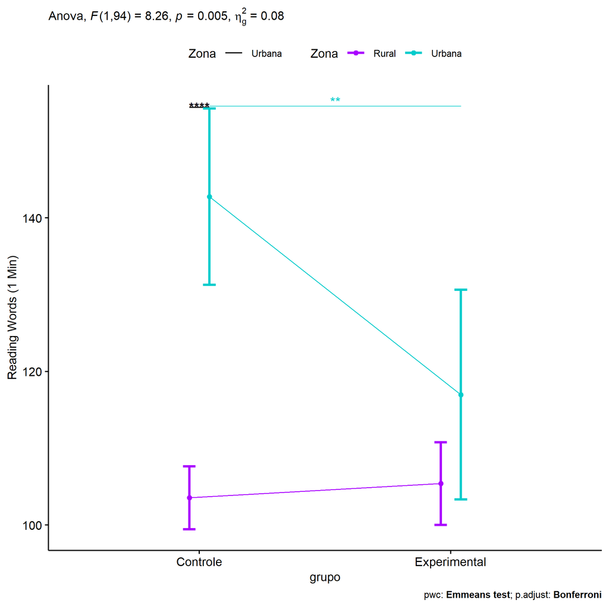

```r
if (length(unique(pdat[["Zona"]])) >= 2) {
  ggPlotAoC2(pwcs, "grupo", "Zona", aov, ylab = "Reading Words (1 Min)",
             subtitle = which(aov$Effect == "grupo:Zona"), addParam = "errorbar") +
    ggplot2::scale_color_manual(values = color[["Zona"]]) +
    if (ymin.ci < ymax.ci) ggplot2::ylim(ymin.ci, ymax.ci)
}
```

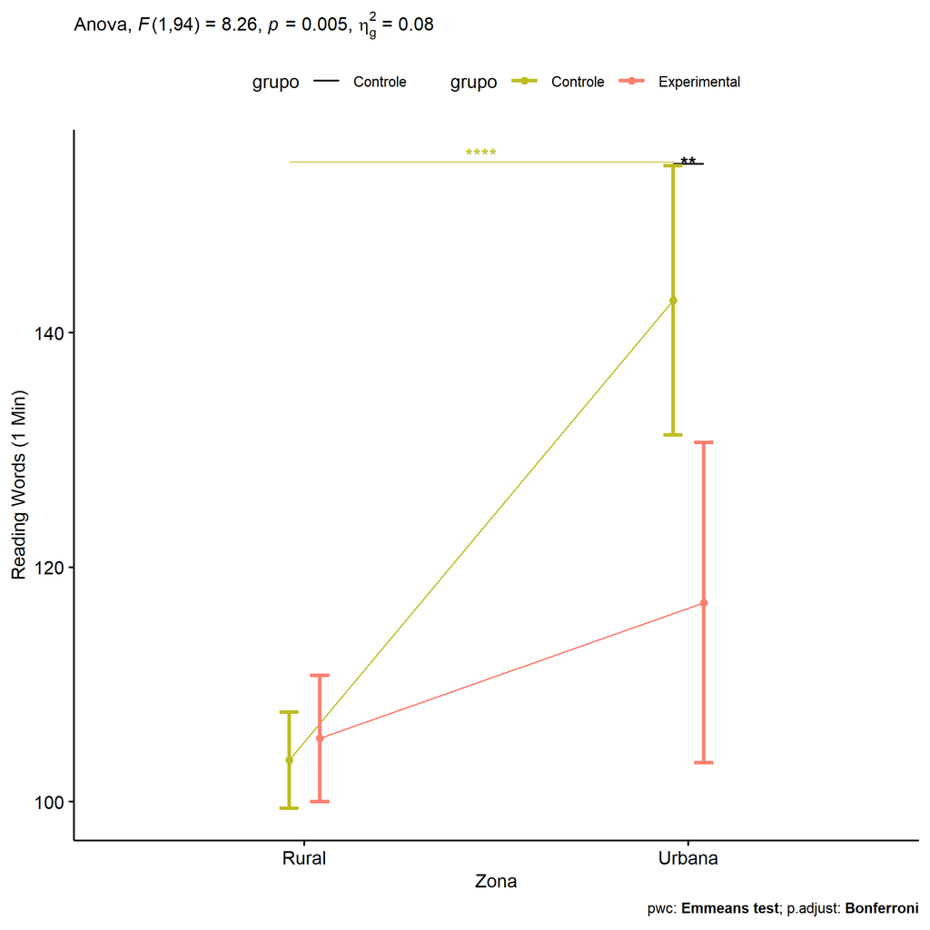

```r
if (length(unique(pdat[["Zona"]])) >= 2) {
  ggPlotAoC2(pwcs, "Zona", "grupo", aov, ylab = "Reading Words (1 Min)",
               subtitle = which(aov$Effect == "grupo:Zona"), addParam = "errorbar") +
      ggplot2::scale_color_manual(values = color[["grupo"]]) +
      if (ymin.ci < ymax.ci) ggplot2::ylim(ymin.ci, ymax.ci)
}
```

```r
if (length(unique(pdat[["Zona"]])) >= 2) {
  plots <- twoWayAncovaBoxPlots(
    wdat, "TFL.lidas.per.min.pos", c("grupo","Zona"), aov, pwcs, covar = "TFL.lidas.per.min.pre",
    theme = "classic", color = color[["grupo:Zona"]],
    subtitle = which(aov$Effect == "grupo:Zona"))
}
```

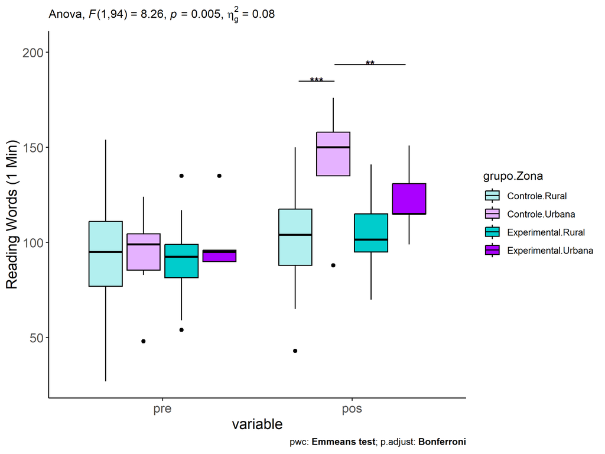

```r
if (length(unique(pdat[["Zona"]])) >= 2) {
  plots[["grupo:Zona"]] + ggplot2::ylab("Reading Words (1 Min)") +
  ggplot2::scale_x_discrete(labels=c('pre', 'pos')) +
  if (ymin < ymax) ggplot2::ylim(ymin, ymax)
}
```

```r
if (length(unique(pdat[["Zona"]])) >= 2) {
  plots <- twoWayAncovaBoxPlots(
    wdat.long, "TFL.lidas.per.min", c("grupo","Zona"), aov, pwc.long,
    pre.post = "time",
    theme = "classic", color = color$prepost)
}
```

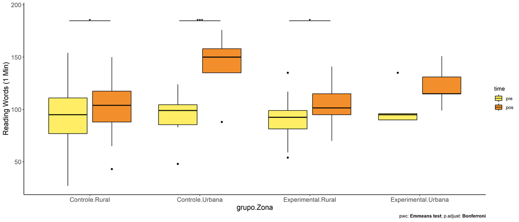

```r
if (length(unique(pdat[["Zona"]])) >= 2)
  plots[["grupo:Zona"]] + ggplot2::ylab("Reading Words (1 Min)") +
    if (ymin < ymax) ggplot2::ylim(ymin, ymax)
```

### Checking linearity assumption

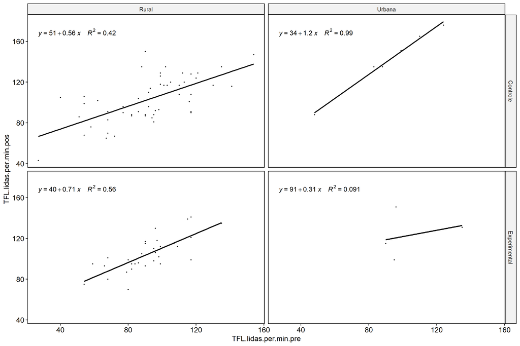

```r
if (length(unique(pdat[["Zona"]])) >= 2) {
  ggscatter(wdat, x = "TFL.lidas.per.min.pre", y = "TFL.lidas.per.min.pos", size = 0.5,
            facet.by = c("grupo","Zona"), add = "reg.line")+
    stat_regline_equation(
      aes(label =  paste(..eq.label.., ..rr.label.., sep = "~~~~"))
    ) +
    if (ymin < ymax) ggplot2::ylim(ymin, ymax)
}
```

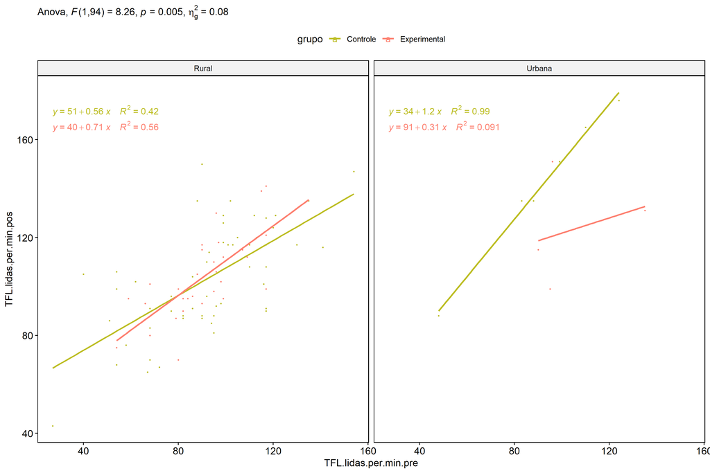

```r
if (length(unique(pdat[["Zona"]])) >= 2) {
  ggscatter(wdat, x = "TFL.lidas.per.min.pre", y = "TFL.lidas.per.min.pos", size = 0.5,
            color = "grupo", facet.by = "Zona", add = "reg.line")+
    stat_regline_equation(
      aes(label =  paste(..eq.label.., ..rr.label.., sep = "~~~~"), color = grupo)
    ) +
    ggplot2::labs(subtitle = rstatix::get_test_label(aov, detailed = T, row = which(aov$Effect == "grupo:Zona"))) +
    ggplot2::scale_color_manual(values = color[["grupo"]]) +
    if (ymin < ymax) ggplot2::ylim(ymin, ymax)
}
```

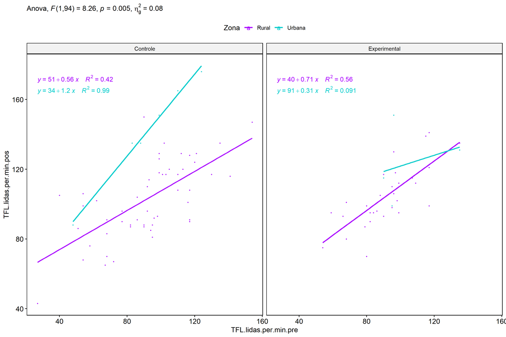

```r
if (length(unique(pdat[["Zona"]])) >= 2) {
  ggscatter(wdat, x = "TFL.lidas.per.min.pre", y = "TFL.lidas.per.min.pos", size = 0.5,
            color = "Zona", facet.by = "grupo", add = "reg.line")+
    stat_regline_equation(
      aes(label =  paste(..eq.label.., ..rr.label.., sep = "~~~~"), color = Zona)
    ) +
    ggplot2::labs(subtitle = rstatix::get_test_label(aov, detailed = T, row = which(aov$Effect == "grupo:Zona"))) +
    ggplot2::scale_color_manual(values = color[["Zona"]]) +
    if (ymin < ymax) ggplot2::ylim(ymin, ymax)
}
```

### Checking normality and homogeneity

```r
if (length(unique(pdat[["Zona"]])) >= 2)
  res <- augment(lm(TFL.lidas.per.min.pos ~ TFL.lidas.per.min.pre + grupo*Zona, data = wdat))
```

```r
if (length(unique(pdat[["Zona"]])) >= 2)
  shapiro_test(res$.resid)
```

```
## # A tibble: 1 × 3
##   variable   statistic p.value
##   <chr>          <dbl>   <dbl>
## 1 res$.resid     0.982   0.212
```

```r
if (length(unique(pdat[["Zona"]])) >= 2)
  levene_test(res, .resid ~ grupo*Zona)
```

```
## # A tibble: 1 × 4
##     df1   df2 statistic     p
##   <int> <int>     <dbl> <dbl>
## 1     3    95      2.06 0.111
```

# ANCOVA and Pairwise for two factors **grupo:Cor.Raca**

## Without remove non-normal data

```r
pdat = remove_group_data(dat[!is.na(dat[["grupo"]]) & !is.na(dat[["Cor.Raca"]]),],
                         "TFL.lidas.per.min.pos", c("grupo","Cor.Raca"))
pdat = pdat[pdat[["Cor.Raca"]] %in% do.call(
  intersect, lapply(unique(pdat[["grupo"]]), FUN = function(x) {
    unique(pdat[["Cor.Raca"]][which(pdat[["grupo"]] == x)])
  })),]
pdat[["grupo"]] = factor(pdat[["grupo"]], level[["grupo"]])
pdat[["Cor.Raca"]] = factor(
  pdat[["Cor.Raca"]],
  level[["Cor.Raca"]][level[["Cor.Raca"]] %in% unique(pdat[["Cor.Raca"]])])

pdat.long <- rbind(pdat[,c("id","grupo","Cor.Raca")], pdat[,c("id","grupo","Cor.Raca")])
pdat.long[["time"]] <- c(rep("pre", nrow(pdat)), rep("pos", nrow(pdat)))
pdat.long[["time"]] <- factor(pdat.long[["time"]], c("pre","pos"))
pdat.long[["TFL.lidas.per.min"]] <- c(pdat[["TFL.lidas.per.min.pre"]], pdat[["TFL.lidas.per.min.pos"]])

if (length(unique(pdat[["Cor.Raca"]])) >= 2) {
  aov = anova_test(pdat, TFL.lidas.per.min.pos ~ TFL.lidas.per.min.pre + grupo*Cor.Raca)
  laov[["grupo:Cor.Raca"]] <- get_anova_table(aov)
}
```

```r
if (length(unique(pdat[["Cor.Raca"]])) >= 2) {
  pwcs <- list()
  pwcs[["Cor.Raca"]] <- emmeans_test(
    group_by(pdat, grupo), TFL.lidas.per.min.pos ~ Cor.Raca,
    covariate = TFL.lidas.per.min.pre, p.adjust.method = "bonferroni")
  pwcs[["grupo"]] <- emmeans_test(
    group_by(pdat, Cor.Raca), TFL.lidas.per.min.pos ~ grupo,
    covariate = TFL.lidas.per.min.pre, p.adjust.method = "bonferroni")

  pwc <- plyr::rbind.fill(pwcs[["grupo"]], pwcs[["Cor.Raca"]])
  pwc <- pwc[,c("grupo","Cor.Raca", colnames(pwc)[!colnames(pwc) %in% c("grupo","Cor.Raca")])]
}
```

```r
if (length(unique(pdat[["Cor.Raca"]])) >= 2) {
  pwc.long <- emmeans_test(dplyr::group_by_at(pdat.long, c("grupo","Cor.Raca")),
                           TFL.lidas.per.min ~ time,
                           p.adjust.method = "bonferroni")
  lpwc[["grupo:Cor.Raca"]] <- plyr::rbind.fill(pwc, pwc.long)
}
```

```r
if (length(unique(pdat[["Cor.Raca"]])) >= 2) {
  ds <- get.descriptives(pdat, "TFL.lidas.per.min.pos", c("grupo","Cor.Raca"), covar = "TFL.lidas.per.min.pre")
  ds <- merge(ds[ds$variable != "TFL.lidas.per.min.pre",],
              ds[ds$variable == "TFL.lidas.per.min.pre", !colnames(ds) %in% c("variable")],
              by = c("grupo","Cor.Raca"), all.x = T, suffixes = c("", ".TFL.lidas.per.min.pre"))
  ds <- merge(get_emmeans(pwcs[["grupo"]]), ds,
              by = c("grupo","Cor.Raca"), suffixes = c(".emms", ""))
  ds <- ds[,c("grupo","Cor.Raca","n","mean.TFL.lidas.per.min.pre","se.TFL.lidas.per.min.pre","mean","se",
              "emmean","se.emms","conf.low","conf.high")]

  colnames(ds) <- c("grupo","Cor.Raca", "N", paste0(c("M","SE")," (pre)"),
                    paste0(c("M","SE"), " (unadj)"),
                    paste0(c("M", "SE"), " (adj)"), "conf.low", "conf.high")

  lemms[["grupo:Cor.Raca"]] <- ds
}
```

## Computing ANCOVA and PairWise After removing non-normal data (OK)

```r
if (length(unique(pdat[["Cor.Raca"]])) >= 2) {
  wdat = pdat

  res = residuals(lm(TFL.lidas.per.min.pos ~ TFL.lidas.per.min.pre + grupo*Cor.Raca, data = wdat))
  non.normal = getNonNormal(res, wdat$id, plimit = 0.05)

  wdat = wdat[!wdat$id %in% non.normal,]

  wdat.long <- rbind(wdat[,c("id","grupo","Cor.Raca")], wdat[,c("id","grupo","Cor.Raca")])
  wdat.long[["time"]] <- c(rep("pre", nrow(wdat)), rep("pos", nrow(wdat)))
  wdat.long[["time"]] <- factor(wdat.long[["time"]], c("pre","pos"))
  wdat.long[["TFL.lidas.per.min"]] <- c(wdat[["TFL.lidas.per.min.pre"]], wdat[["TFL.lidas.per.min.pos"]])


  ldat[["grupo:Cor.Raca"]] = wdat

  (non.normal)
}
```

```
## [1] "P510" "P945"
```

```r
if (length(unique(pdat[["Cor.Raca"]])) >= 2) {
  aov = anova_test(wdat, TFL.lidas.per.min.pos ~ TFL.lidas.per.min.pre + grupo*Cor.Raca)
  laov[["grupo:Cor.Raca"]] <- merge(get_anova_table(aov), laov[["grupo:Cor.Raca"]],
                                         by="Effect", suffixes = c("","'"))
  df = get_anova_table(aov)
}
```

| Effect | DFn | DFd | F | p | p<.05 | ges |
| --- | --- | --- | --- | --- | --- | --- |
| TFL.lidas.per.min.pre | 1 | 68 | 54.835 | 0.000 | * | 0.446 |
| grupo | 1 | 68 | 2.749 | 0.102 |  | 0.039 |
| Cor.Raca | 1 | 68 | 2.633 | 0.109 |  | 0.037 |
| grupo:Cor.Raca | 1 | 68 | 1.775 | 0.187 |  | 0.025 |

```r
if (length(unique(pdat[["Cor.Raca"]])) >= 2) {
  pwcs <- list()
  pwcs[["Cor.Raca"]] <- emmeans_test(
    group_by(wdat, grupo), TFL.lidas.per.min.pos ~ Cor.Raca,
    covariate = TFL.lidas.per.min.pre, p.adjust.method = "bonferroni")
  pwcs[["grupo"]] <- emmeans_test(
    group_by(wdat, Cor.Raca), TFL.lidas.per.min.pos ~ grupo,
    covariate = TFL.lidas.per.min.pre, p.adjust.method = "bonferroni")

  pwc <- plyr::rbind.fill(pwcs[["grupo"]], pwcs[["Cor.Raca"]])
  pwc <- pwc[,c("grupo","Cor.Raca", colnames(pwc)[!colnames(pwc) %in% c("grupo","Cor.Raca")])]
}
```

| grupo | Cor.Raca | term | .y. | group1 | group2 | df | statistic | p | p.adj | p.adj.signif |
| --- | --- | --- | --- | --- | --- | --- | --- | --- | --- | --- |
|  | Parda | TFL.lidas.per.min.pre*grupo | TFL.lidas.per.min.pos | Controle | Experimental | 68 | -0.818 | 0.416 | 0.416 | ns |
|  | Branca | TFL.lidas.per.min.pre*grupo | TFL.lidas.per.min.pos | Controle | Experimental | 68 | -1.965 | 0.054 | 0.054 | ns |
| Controle |  | TFL.lidas.per.min.pre*Cor.Raca | TFL.lidas.per.min.pos | Parda | Branca | 68 | -0.658 | 0.513 | 0.513 | ns |
| Experimental |  | TFL.lidas.per.min.pre*Cor.Raca | TFL.lidas.per.min.pos | Parda | Branca | 68 | -2.019 | 0.047 | 0.047 | * |

```r
if (length(unique(pdat[["Cor.Raca"]])) >= 2) {
  pwc.long <- emmeans_test(dplyr::group_by_at(wdat.long, c("grupo","Cor.Raca")),
                           TFL.lidas.per.min ~ time,
                           p.adjust.method = "bonferroni")
  lpwc[["grupo:Cor.Raca"]] <- merge(plyr::rbind.fill(pwc, pwc.long),
                                         lpwc[["grupo:Cor.Raca"]],
                                         by=c("grupo","Cor.Raca","term",".y.","group1","group2"),
                                         suffixes = c("","'"))
}
```

| grupo | Cor.Raca | term | .y. | group1 | group2 | df | statistic | p | p.adj | p.adj.signif |
| --- | --- | --- | --- | --- | --- | --- | --- | --- | --- | --- |
| Controle | Parda | time | TFL.lidas.per.min | pre | pos | 138 | -1.587 | 0.115 | 0.115 | ns |
| Controle | Branca | time | TFL.lidas.per.min | pre | pos | 138 | -0.605 | 0.546 | 0.546 | ns |
| Experimental | Parda | time | TFL.lidas.per.min | pre | pos | 138 | -1.640 | 0.103 | 0.103 | ns |
| Experimental | Branca | time | TFL.lidas.per.min | pre | pos | 138 | -1.718 | 0.088 | 0.088 | ns |

```r
if (length(unique(pdat[["Cor.Raca"]])) >= 2) {
  ds <- get.descriptives(wdat, "TFL.lidas.per.min.pos", c("grupo","Cor.Raca"), covar = "TFL.lidas.per.min.pre")
  ds <- merge(ds[ds$variable != "TFL.lidas.per.min.pre",],
              ds[ds$variable == "TFL.lidas.per.min.pre", !colnames(ds) %in% c("variable")],
              by = c("grupo","Cor.Raca"), all.x = T, suffixes = c("", ".TFL.lidas.per.min.pre"))
  ds <- merge(get_emmeans(pwcs[["grupo"]]), ds,
              by = c("grupo","Cor.Raca"), suffixes = c(".emms", ""))
  ds <- ds[,c("grupo","Cor.Raca","n","mean.TFL.lidas.per.min.pre","se.TFL.lidas.per.min.pre",
              "mean","se","emmean","se.emms","conf.low","conf.high")]

  colnames(ds) <- c("grupo","Cor.Raca", "N", paste0(c("M","SE")," (pre)"),
                    paste0(c("M","SE"), " (unadj)"),
                    paste0(c("M", "SE"), " (adj)"), "conf.low", "conf.high")

  lemms[["grupo:Cor.Raca"]] <- merge(ds, lemms[["grupo:Cor.Raca"]],
                                          by=c("grupo","Cor.Raca"), suffixes = c("","'"))
}
```

| grupo | Cor.Raca | N | M (pre) | SE (pre) | M (unadj) | SE (unadj) | M (adj) | SE (adj) | conf.low | conf.high |
| --- | --- | --- | --- | --- | --- | --- | --- | --- | --- | --- |
| Controle | Branca | 11 | 106.909 | 4.783 | 112.273 | 4.589 | 104.105 | 4.735 | 94.656 | 113.554 |
| Controle | Parda | 41 | 91.707 | 3.649 | 99.000 | 3.449 | 100.585 | 2.395 | 95.806 | 105.364 |
| Experimental | Branca | 5 | 104.000 | 5.310 | 126.600 | 8.322 | 120.298 | 6.883 | 106.563 | 134.033 |
| Experimental | Parda | 16 | 88.688 | 5.065 | 100.750 | 4.760 | 104.273 | 3.848 | 96.595 | 111.951 |

### Plots for ancova

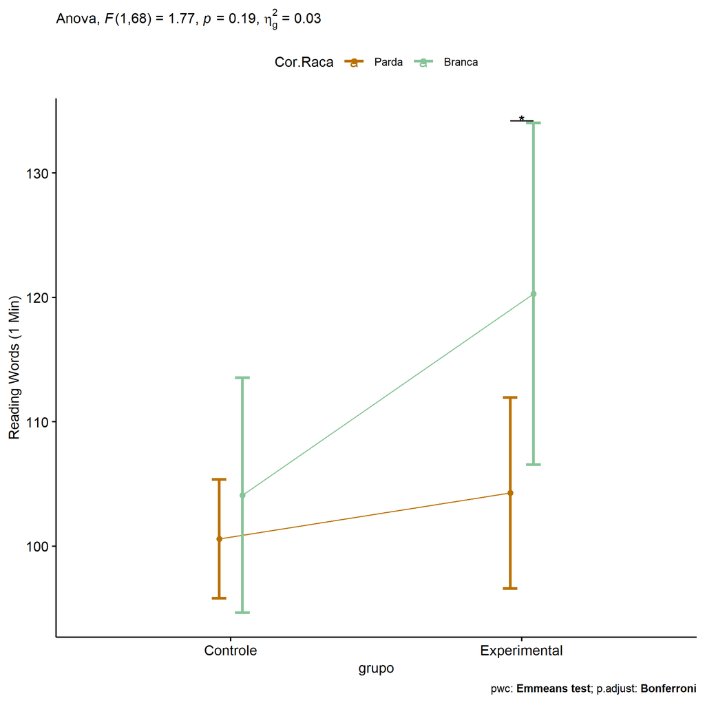

```r
if (length(unique(pdat[["Cor.Raca"]])) >= 2) {
  ggPlotAoC2(pwcs, "grupo", "Cor.Raca", aov, ylab = "Reading Words (1 Min)",
             subtitle = which(aov$Effect == "grupo:Cor.Raca"), addParam = "errorbar") +
    ggplot2::scale_color_manual(values = color[["Cor.Raca"]]) +
    if (ymin.ci < ymax.ci) ggplot2::ylim(ymin.ci, ymax.ci)
}
```

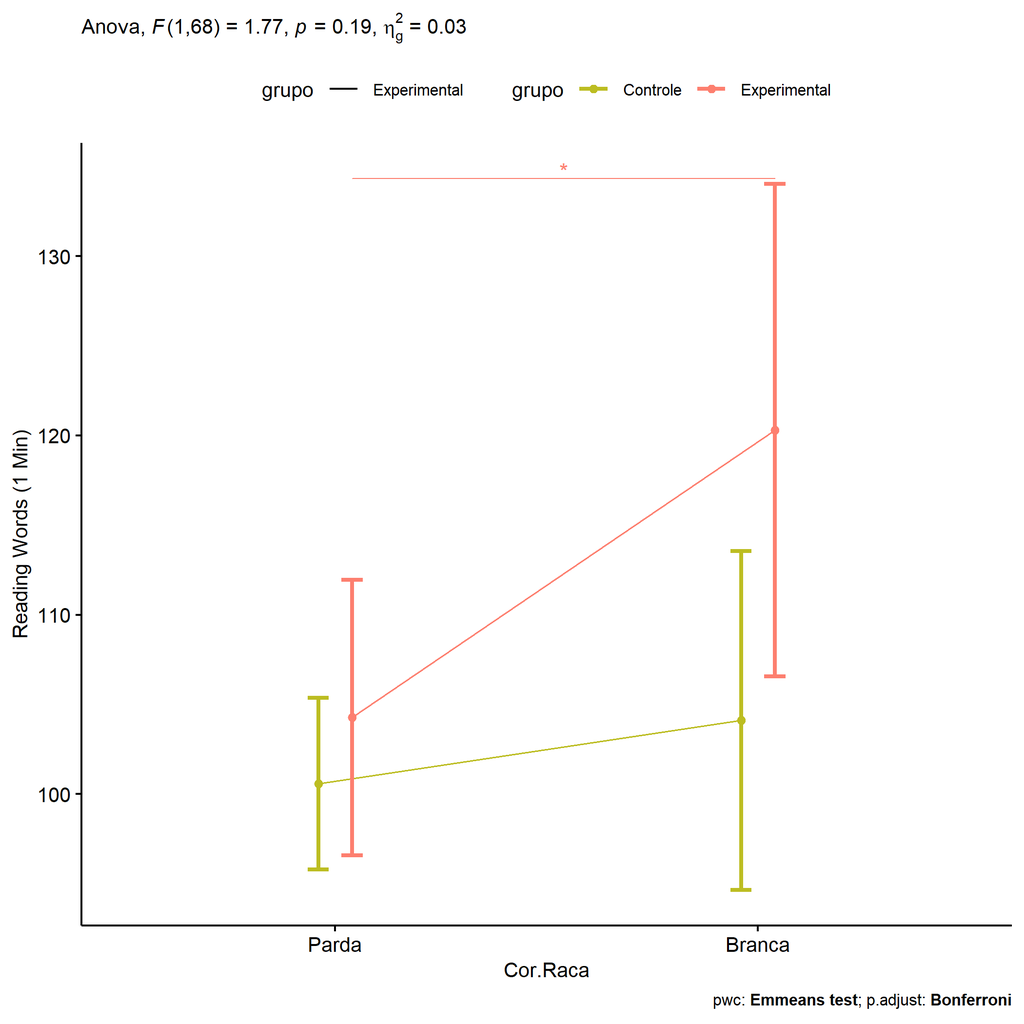

```r
if (length(unique(pdat[["Cor.Raca"]])) >= 2) {
  ggPlotAoC2(pwcs, "Cor.Raca", "grupo", aov, ylab = "Reading Words (1 Min)",
               subtitle = which(aov$Effect == "grupo:Cor.Raca"), addParam = "errorbar") +
      ggplot2::scale_color_manual(values = color[["grupo"]]) +
      if (ymin.ci < ymax.ci) ggplot2::ylim(ymin.ci, ymax.ci)
}
```

```r
if (length(unique(pdat[["Cor.Raca"]])) >= 2) {
  plots <- twoWayAncovaBoxPlots(
    wdat, "TFL.lidas.per.min.pos", c("grupo","Cor.Raca"), aov, pwcs, covar = "TFL.lidas.per.min.pre",
    theme = "classic", color = color[["grupo:Cor.Raca"]],
    subtitle = which(aov$Effect == "grupo:Cor.Raca"))
}
```

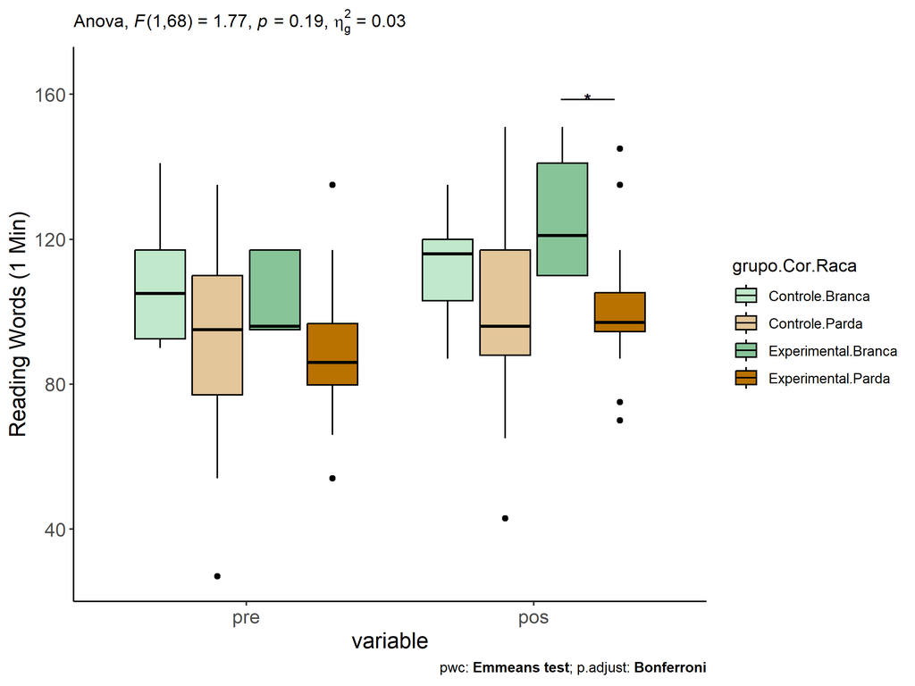

```r
if (length(unique(pdat[["Cor.Raca"]])) >= 2) {
  plots[["grupo:Cor.Raca"]] + ggplot2::ylab("Reading Words (1 Min)") +
  ggplot2::scale_x_discrete(labels=c('pre', 'pos')) +
  if (ymin < ymax) ggplot2::ylim(ymin, ymax)
}
```

```r
if (length(unique(pdat[["Cor.Raca"]])) >= 2) {
  plots <- twoWayAncovaBoxPlots(
    wdat.long, "TFL.lidas.per.min", c("grupo","Cor.Raca"), aov, pwc.long,
    pre.post = "time",
    theme = "classic", color = color$prepost)
}
```

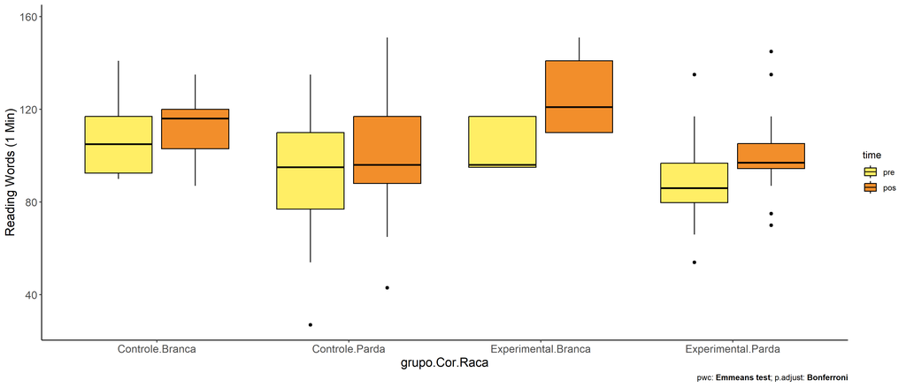

```r
if (length(unique(pdat[["Cor.Raca"]])) >= 2)
  plots[["grupo:Cor.Raca"]] + ggplot2::ylab("Reading Words (1 Min)") +
    if (ymin < ymax) ggplot2::ylim(ymin, ymax)
```

### Checking linearity assumption

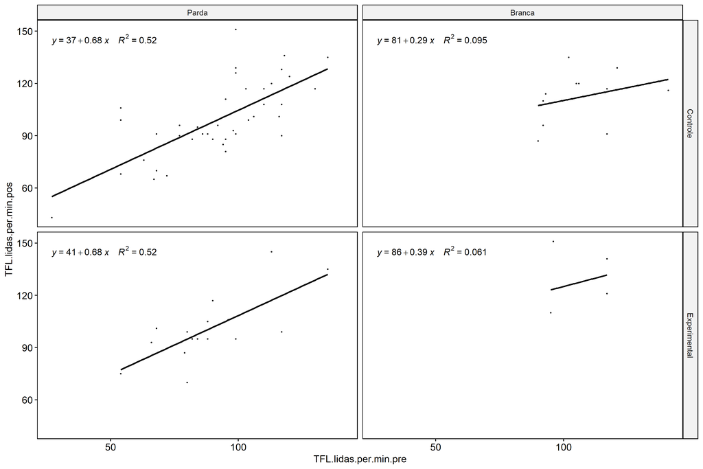

```r
if (length(unique(pdat[["Cor.Raca"]])) >= 2) {
  ggscatter(wdat, x = "TFL.lidas.per.min.pre", y = "TFL.lidas.per.min.pos", size = 0.5,
            facet.by = c("grupo","Cor.Raca"), add = "reg.line")+
    stat_regline_equation(
      aes(label =  paste(..eq.label.., ..rr.label.., sep = "~~~~"))
    ) +
    if (ymin < ymax) ggplot2::ylim(ymin, ymax)
}
```

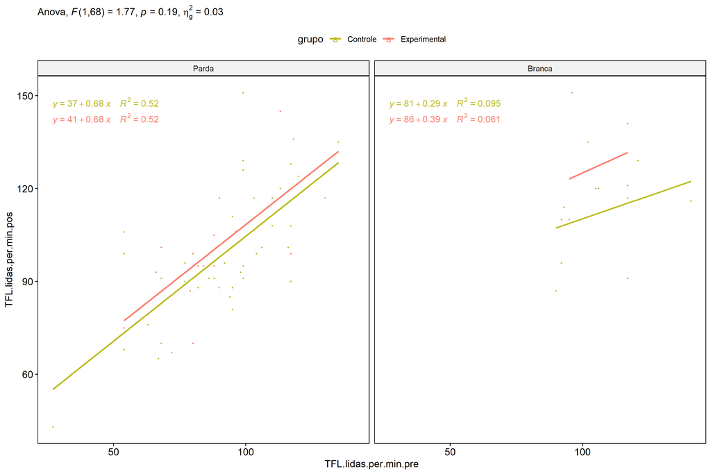

```r
if (length(unique(pdat[["Cor.Raca"]])) >= 2) {
  ggscatter(wdat, x = "TFL.lidas.per.min.pre", y = "TFL.lidas.per.min.pos", size = 0.5,
            color = "grupo", facet.by = "Cor.Raca", add = "reg.line")+
    stat_regline_equation(
      aes(label =  paste(..eq.label.., ..rr.label.., sep = "~~~~"), color = grupo)
    ) +
    ggplot2::labs(subtitle = rstatix::get_test_label(aov, detailed = T, row = which(aov$Effect == "grupo:Cor.Raca"))) +
    ggplot2::scale_color_manual(values = color[["grupo"]]) +
    if (ymin < ymax) ggplot2::ylim(ymin, ymax)
}
```

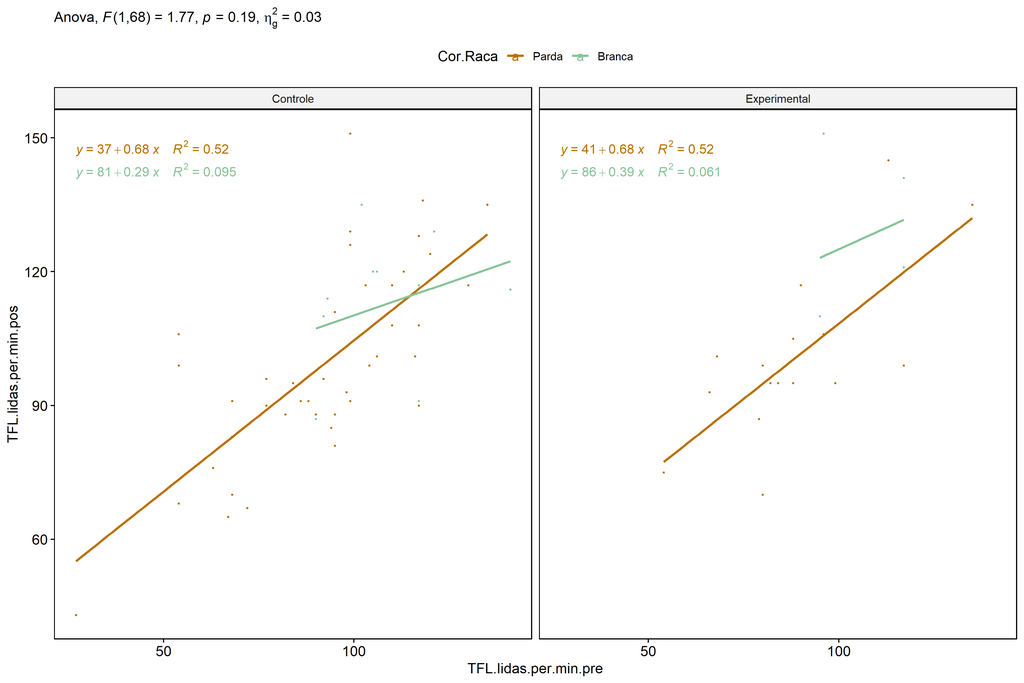

```r
if (length(unique(pdat[["Cor.Raca"]])) >= 2) {
  ggscatter(wdat, x = "TFL.lidas.per.min.pre", y = "TFL.lidas.per.min.pos", size = 0.5,
            color = "Cor.Raca", facet.by = "grupo", add = "reg.line")+
    stat_regline_equation(
      aes(label =  paste(..eq.label.., ..rr.label.., sep = "~~~~"), color = Cor.Raca)
    ) +
    ggplot2::labs(subtitle = rstatix::get_test_label(aov, detailed = T, row = which(aov$Effect == "grupo:Cor.Raca"))) +
    ggplot2::scale_color_manual(values = color[["Cor.Raca"]]) +
    if (ymin < ymax) ggplot2::ylim(ymin, ymax)
}
```

### Checking normality and homogeneity

```r
if (length(unique(pdat[["Cor.Raca"]])) >= 2)
  res <- augment(lm(TFL.lidas.per.min.pos ~ TFL.lidas.per.min.pre + grupo*Cor.Raca, data = wdat))
```

```r
if (length(unique(pdat[["Cor.Raca"]])) >= 2)
  shapiro_test(res$.resid)
```

```
## # A tibble: 1 × 3
##   variable   statistic p.value
##   <chr>          <dbl>   <dbl>
## 1 res$.resid     0.968  0.0636
```

```r
if (length(unique(pdat[["Cor.Raca"]])) >= 2)
  levene_test(res, .resid ~ grupo*Cor.Raca)
```

```
## # A tibble: 1 × 4
##     df1   df2 statistic     p
##   <int> <int>     <dbl> <dbl>
## 1     3    69     0.135 0.939
```

# ANCOVA and Pairwise for two factors **grupo:Serie**

## Without remove non-normal data

```r
pdat = remove_group_data(dat[!is.na(dat[["grupo"]]) & !is.na(dat[["Serie"]]),],
                         "TFL.lidas.per.min.pos", c("grupo","Serie"))
pdat = pdat[pdat[["Serie"]] %in% do.call(
  intersect, lapply(unique(pdat[["grupo"]]), FUN = function(x) {
    unique(pdat[["Serie"]][which(pdat[["grupo"]] == x)])
  })),]
pdat[["grupo"]] = factor(pdat[["grupo"]], level[["grupo"]])
pdat[["Serie"]] = factor(
  pdat[["Serie"]],
  level[["Serie"]][level[["Serie"]] %in% unique(pdat[["Serie"]])])

pdat.long <- rbind(pdat[,c("id","grupo","Serie")], pdat[,c("id","grupo","Serie")])
pdat.long[["time"]] <- c(rep("pre", nrow(pdat)), rep("pos", nrow(pdat)))
pdat.long[["time"]] <- factor(pdat.long[["time"]], c("pre","pos"))
pdat.long[["TFL.lidas.per.min"]] <- c(pdat[["TFL.lidas.per.min.pre"]], pdat[["TFL.lidas.per.min.pos"]])

if (length(unique(pdat[["Serie"]])) >= 2) {
  aov = anova_test(pdat, TFL.lidas.per.min.pos ~ TFL.lidas.per.min.pre + grupo*Serie)
  laov[["grupo:Serie"]] <- get_anova_table(aov)
}
```

```r
if (length(unique(pdat[["Serie"]])) >= 2) {
  pwcs <- list()
  pwcs[["Serie"]] <- emmeans_test(
    group_by(pdat, grupo), TFL.lidas.per.min.pos ~ Serie,
    covariate = TFL.lidas.per.min.pre, p.adjust.method = "bonferroni")
  pwcs[["grupo"]] <- emmeans_test(
    group_by(pdat, Serie), TFL.lidas.per.min.pos ~ grupo,
    covariate = TFL.lidas.per.min.pre, p.adjust.method = "bonferroni")

  pwc <- plyr::rbind.fill(pwcs[["grupo"]], pwcs[["Serie"]])
  pwc <- pwc[,c("grupo","Serie", colnames(pwc)[!colnames(pwc) %in% c("grupo","Serie")])]
}
```

```r
if (length(unique(pdat[["Serie"]])) >= 2) {
  pwc.long <- emmeans_test(dplyr::group_by_at(pdat.long, c("grupo","Serie")),
                           TFL.lidas.per.min ~ time,
                           p.adjust.method = "bonferroni")
  lpwc[["grupo:Serie"]] <- plyr::rbind.fill(pwc, pwc.long)
}
```

```r
if (length(unique(pdat[["Serie"]])) >= 2) {
  ds <- get.descriptives(pdat, "TFL.lidas.per.min.pos", c("grupo","Serie"), covar = "TFL.lidas.per.min.pre")
  ds <- merge(ds[ds$variable != "TFL.lidas.per.min.pre",],
              ds[ds$variable == "TFL.lidas.per.min.pre", !colnames(ds) %in% c("variable")],
              by = c("grupo","Serie"), all.x = T, suffixes = c("", ".TFL.lidas.per.min.pre"))
  ds <- merge(get_emmeans(pwcs[["grupo"]]), ds,
              by = c("grupo","Serie"), suffixes = c(".emms", ""))
  ds <- ds[,c("grupo","Serie","n","mean.TFL.lidas.per.min.pre","se.TFL.lidas.per.min.pre","mean","se",
              "emmean","se.emms","conf.low","conf.high")]

  colnames(ds) <- c("grupo","Serie", "N", paste0(c("M","SE")," (pre)"),
                    paste0(c("M","SE"), " (unadj)"),
                    paste0(c("M", "SE"), " (adj)"), "conf.low", "conf.high")

  lemms[["grupo:Serie"]] <- ds
}
```

## Computing ANCOVA and PairWise After removing non-normal data (OK)

```r
if (length(unique(pdat[["Serie"]])) >= 2) {
  wdat = pdat

  res = residuals(lm(TFL.lidas.per.min.pos ~ TFL.lidas.per.min.pre + grupo*Serie, data = wdat))
  non.normal = getNonNormal(res, wdat$id, plimit = 0.05)

  wdat = wdat[!wdat$id %in% non.normal,]

  wdat.long <- rbind(wdat[,c("id","grupo","Serie")], wdat[,c("id","grupo","Serie")])
  wdat.long[["time"]] <- c(rep("pre", nrow(wdat)), rep("pos", nrow(wdat)))
  wdat.long[["time"]] <- factor(wdat.long[["time"]], c("pre","pos"))
  wdat.long[["TFL.lidas.per.min"]] <- c(wdat[["TFL.lidas.per.min.pre"]], wdat[["TFL.lidas.per.min.pos"]])


  ldat[["grupo:Serie"]] = wdat

  (non.normal)
}
```

```
##  [1] "P3609" "P3498" "P1010" "P3721" "P956"  "P808"  "P3729" "P1109" "P1017" "P463"  "P1091"
## [12] "P820"  "P1094" "P621"  "P628"  "P133"  "P994"  "P1097" "P3516" "P1716" "P3505" "P942"
## [23] "P3581" "P128"  "P445"  "P3627" "P3521" "P3504" "P3566" "P446"  "P997"  "P616"  "P1089"
## [34] "P829"  "P3615" "P947"  "P465"  "P3492" "P451"  "P184"  "P618"  "P614"  "P2210" "P3606"
## [45] "P950"  "P3558" "P3624" "P3501" "P1004" "P3734" "P816"  "P1000" "P3509" "P1107" "P3565"
## [56] "P3495" "P615"  "P625"  "P612"  "P241"  "P3512" "P3524" "P521"  "P3502" "P620"  "P1084"
## [67] "P626"  "P613"  "P812"  "P2239" "P448"  "P936"  "P3518" "P513"  "P516"  "P3598" "P143"
## [78] "P1742" "P515"  "P459"  "P3560" "P958"  "P523"  "P460"  "P813"  "P948"  "P622"  "P457"
## [89] "P943"  "P512"  "P238"  "P3569" "P464"  "P449"  "P3519" "P2249" "P3577" "P121"  "P176"
```

```r
if (length(unique(pdat[["Serie"]])) >= 2) {
  aov = anova_test(wdat, TFL.lidas.per.min.pos ~ TFL.lidas.per.min.pre + grupo*Serie)
  laov[["grupo:Serie"]] <- merge(get_anova_table(aov), laov[["grupo:Serie"]],
                                         by="Effect", suffixes = c("","'"))
  df = get_anova_table(aov)
}
```

| Effect | DFn | DFd | F | p | p<.05 | ges |
| --- | --- | --- | --- | --- | --- | --- |
| TFL.lidas.per.min.pre | 1 | 36 | 78.106 | 0.000 | * | 0.685 |
| grupo | 1 | 36 | 0.017 | 0.896 |  | 0.000 |
| Serie | 3 | 36 | 2.179 | 0.107 |  | 0.154 |
| grupo:Serie | 3 | 36 | 10.000 | 0.000 | * | 0.455 |

```r
if (length(unique(pdat[["Serie"]])) >= 2) {
  pwcs <- list()
  pwcs[["Serie"]] <- emmeans_test(
    group_by(wdat, grupo), TFL.lidas.per.min.pos ~ Serie,
    covariate = TFL.lidas.per.min.pre, p.adjust.method = "bonferroni")
  pwcs[["grupo"]] <- emmeans_test(
    group_by(wdat, Serie), TFL.lidas.per.min.pos ~ grupo,
    covariate = TFL.lidas.per.min.pre, p.adjust.method = "bonferroni")

  pwc <- plyr::rbind.fill(pwcs[["grupo"]], pwcs[["Serie"]])
  pwc <- pwc[,c("grupo","Serie", colnames(pwc)[!colnames(pwc) %in% c("grupo","Serie")])]
}
```

| grupo | Serie | term | .y. | group1 | group2 | df | statistic | p | p.adj | p.adj.signif |
| --- | --- | --- | --- | --- | --- | --- | --- | --- | --- | --- |
|  | 6 ano | TFL.lidas.per.min.pre*grupo | TFL.lidas.per.min.pos | Controle | Experimental | 36 | -4.437 | 0.000 | 0.000 | **** |
|  | 7 ano | TFL.lidas.per.min.pre*grupo | TFL.lidas.per.min.pos | Controle | Experimental | 36 | 1.780 | 0.083 | 0.083 | ns |
|  | 8 ano | TFL.lidas.per.min.pre*grupo | TFL.lidas.per.min.pos | Controle | Experimental | 36 | 2.164 | 0.037 | 0.037 | * |
|  | 9 ano | TFL.lidas.per.min.pre*grupo | TFL.lidas.per.min.pos | Controle | Experimental | 36 | 1.877 | 0.069 | 0.069 | ns |
| Controle |  | TFL.lidas.per.min.pre*Serie | TFL.lidas.per.min.pos | 6 ano | 7 ano | 36 | -1.107 | 0.275 | 1.000 | ns |
| Controle |  | TFL.lidas.per.min.pre*Serie | TFL.lidas.per.min.pos | 6 ano | 8 ano | 36 | -3.368 | 0.002 | 0.011 | * |
| Controle |  | TFL.lidas.per.min.pre*Serie | TFL.lidas.per.min.pos | 6 ano | 9 ano | 36 | -3.410 | 0.002 | 0.010 | ** |
| Controle |  | TFL.lidas.per.min.pre*Serie | TFL.lidas.per.min.pos | 7 ano | 8 ano | 36 | -1.843 | 0.074 | 0.441 | ns |
| Controle |  | TFL.lidas.per.min.pre*Serie | TFL.lidas.per.min.pos | 7 ano | 9 ano | 36 | -1.697 | 0.098 | 0.589 | ns |
| Controle |  | TFL.lidas.per.min.pre*Serie | TFL.lidas.per.min.pos | 8 ano | 9 ano | 36 | 0.339 | 0.737 | 1.000 | ns |
| Experimental |  | TFL.lidas.per.min.pre*Serie | TFL.lidas.per.min.pos | 6 ano | 7 ano | 36 | 4.062 | 0.000 | 0.002 | ** |
| Experimental |  | TFL.lidas.per.min.pre*Serie | TFL.lidas.per.min.pos | 6 ano | 8 ano | 36 | 3.264 | 0.002 | 0.014 | * |
| Experimental |  | TFL.lidas.per.min.pre*Serie | TFL.lidas.per.min.pos | 6 ano | 9 ano | 36 | 3.069 | 0.004 | 0.024 | * |
| Experimental |  | TFL.lidas.per.min.pre*Serie | TFL.lidas.per.min.pos | 7 ano | 8 ano | 36 | -1.390 | 0.173 | 1.000 | ns |
| Experimental |  | TFL.lidas.per.min.pre*Serie | TFL.lidas.per.min.pos | 7 ano | 9 ano | 36 | -1.289 | 0.205 | 1.000 | ns |
| Experimental |  | TFL.lidas.per.min.pre*Serie | TFL.lidas.per.min.pos | 8 ano | 9 ano | 36 | 0.035 | 0.972 | 1.000 | ns |

```r
if (length(unique(pdat[["Serie"]])) >= 2) {
  pwc.long <- emmeans_test(dplyr::group_by_at(wdat.long, c("grupo","Serie")),
                           TFL.lidas.per.min ~ time,
                           p.adjust.method = "bonferroni")
  lpwc[["grupo:Serie"]] <- merge(plyr::rbind.fill(pwc, pwc.long),
                                         lpwc[["grupo:Serie"]],
                                         by=c("grupo","Serie","term",".y.","group1","group2"),
                                         suffixes = c("","'"))
}
```

| grupo | Serie | term | .y. | group1 | group2 | df | statistic | p | p.adj | p.adj.signif |
| --- | --- | --- | --- | --- | --- | --- | --- | --- | --- | --- |
| Controle | 6 ano | time | TFL.lidas.per.min | pre | pos | 74 | -3.653 | 0.000 | 0.000 | *** |
| Controle | 7 ano | time | TFL.lidas.per.min | pre | pos | 74 | -3.309 | 0.001 | 0.001 | ** |
| Controle | 8 ano | time | TFL.lidas.per.min | pre | pos | 74 | -4.949 | 0.000 | 0.000 | **** |
| Controle | 9 ano | time | TFL.lidas.per.min | pre | pos | 74 | -6.030 | 0.000 | 0.000 | **** |
| Experimental | 6 ano | time | TFL.lidas.per.min | pre | pos | 74 | -4.520 | 0.000 | 0.000 | **** |
| Experimental | 7 ano | time | TFL.lidas.per.min | pre | pos | 74 | -1.073 | 0.287 | 0.287 | ns |
| Experimental | 8 ano | time | TFL.lidas.per.min | pre | pos | 74 | -2.399 | 0.019 | 0.019 | * |
| Experimental | 9 ano | time | TFL.lidas.per.min | pre | pos | 74 | -2.073 | 0.042 | 0.042 | * |

```r
if (length(unique(pdat[["Serie"]])) >= 2) {
  ds <- get.descriptives(wdat, "TFL.lidas.per.min.pos", c("grupo","Serie"), covar = "TFL.lidas.per.min.pre")
  ds <- merge(ds[ds$variable != "TFL.lidas.per.min.pre",],
              ds[ds$variable == "TFL.lidas.per.min.pre", !colnames(ds) %in% c("variable")],
              by = c("grupo","Serie"), all.x = T, suffixes = c("", ".TFL.lidas.per.min.pre"))
  ds <- merge(get_emmeans(pwcs[["grupo"]]), ds,
              by = c("grupo","Serie"), suffixes = c(".emms", ""))
  ds <- ds[,c("grupo","Serie","n","mean.TFL.lidas.per.min.pre","se.TFL.lidas.per.min.pre",
              "mean","se","emmean","se.emms","conf.low","conf.high")]

  colnames(ds) <- c("grupo","Serie", "N", paste0(c("M","SE")," (pre)"),
                    paste0(c("M","SE"), " (unadj)"),
                    paste0(c("M", "SE"), " (adj)"), "conf.low", "conf.high")

  lemms[["grupo:Serie"]] <- merge(ds, lemms[["grupo:Serie"]],
                                          by=c("grupo","Serie"), suffixes = c("","'"))
}
```

| grupo | Serie | N | M (pre) | SE (pre) | M (unadj) | SE (unadj) | M (adj) | SE (adj) | conf.low | conf.high |
| --- | --- | --- | --- | --- | --- | --- | --- | --- | --- | --- |
| Controle | 6 ano | 9 | 88.444 | 9.836 | 127.778 | 7.361 | 129.020 | 4.077 | 120.752 | 137.288 |
| Controle | 7 ano | 5 | 85.000 | 12.116 | 132.800 | 16.387 | 136.577 | 5.483 | 125.457 | 147.696 |
| Controle | 8 ano | 7 | 87.143 | 9.913 | 147.571 | 7.108 | 149.771 | 4.627 | 140.388 | 159.154 |
| Controle | 9 ano | 11 | 86.000 | 6.488 | 144.727 | 5.641 | 147.768 | 3.701 | 140.261 | 155.275 |
| Experimental | 6 ano | 4 | 84.500 | 12.500 | 157.500 | 8.930 | 161.644 | 6.129 | 149.213 | 174.075 |
| Experimental | 7 ano | 2 | 103.500 | 13.500 | 128.000 | 13.000 | 118.166 | 8.714 | 100.493 | 135.840 |
| Experimental | 8 ano | 4 | 105.250 | 5.692 | 144.000 | 7.969 | 132.879 | 6.240 | 120.224 | 145.534 |
| Experimental | 9 ano | 3 | 104.333 | 6.741 | 143.000 | 4.000 | 132.553 | 7.155 | 118.042 | 147.065 |

### Plots for ancova

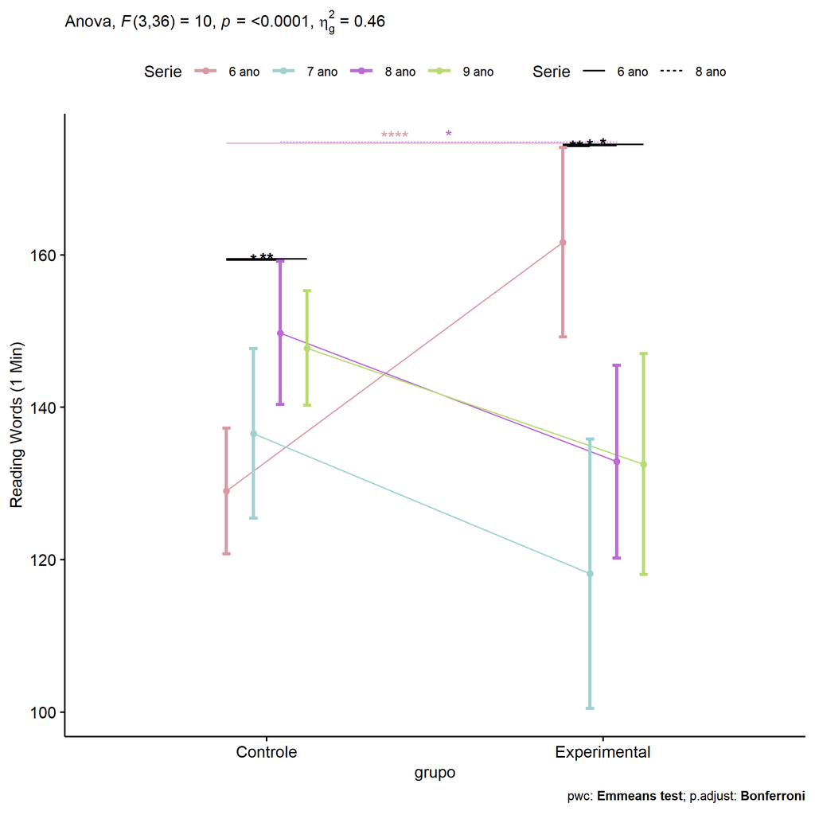

```r
if (length(unique(pdat[["Serie"]])) >= 2) {
  ggPlotAoC2(pwcs, "grupo", "Serie", aov, ylab = "Reading Words (1 Min)",
             subtitle = which(aov$Effect == "grupo:Serie"), addParam = "errorbar") +
    ggplot2::scale_color_manual(values = color[["Serie"]]) +
    if (ymin.ci < ymax.ci) ggplot2::ylim(ymin.ci, ymax.ci)
}
```

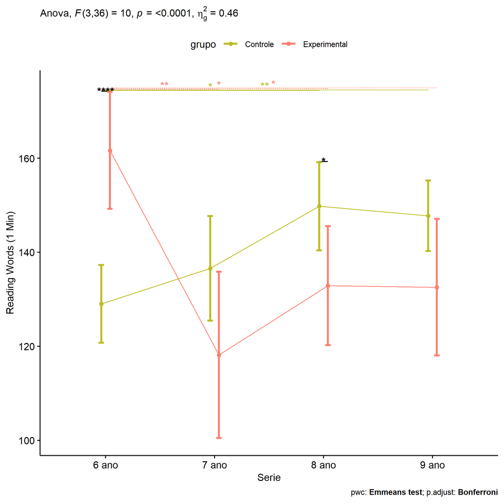

```r
if (length(unique(pdat[["Serie"]])) >= 2) {
  ggPlotAoC2(pwcs, "Serie", "grupo", aov, ylab = "Reading Words (1 Min)",
               subtitle = which(aov$Effect == "grupo:Serie"), addParam = "errorbar") +
      ggplot2::scale_color_manual(values = color[["grupo"]]) +
      if (ymin.ci < ymax.ci) ggplot2::ylim(ymin.ci, ymax.ci)
}
```

```r
if (length(unique(pdat[["Serie"]])) >= 2) {
  plots <- twoWayAncovaBoxPlots(
    wdat, "TFL.lidas.per.min.pos", c("grupo","Serie"), aov, pwcs, covar = "TFL.lidas.per.min.pre",
    theme = "classic", color = color[["grupo:Serie"]],
    subtitle = which(aov$Effect == "grupo:Serie"))
}
```

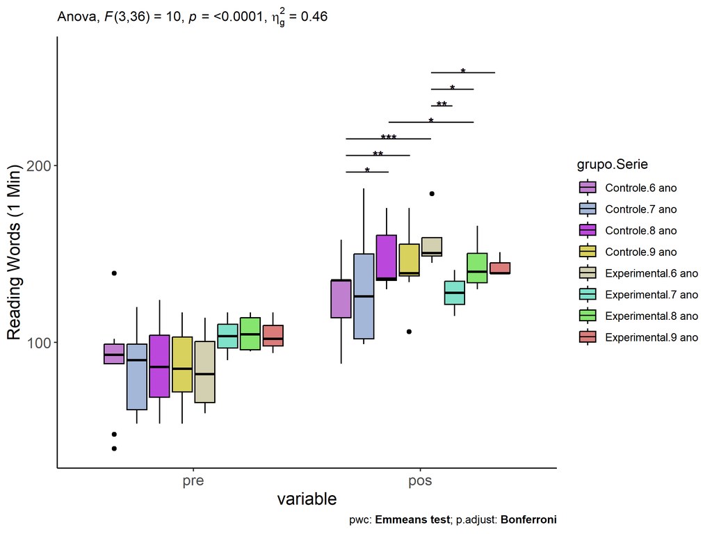

```r
if (length(unique(pdat[["Serie"]])) >= 2) {
  plots[["grupo:Serie"]] + ggplot2::ylab("Reading Words (1 Min)") +
  ggplot2::scale_x_discrete(labels=c('pre', 'pos')) +
  if (ymin < ymax) ggplot2::ylim(ymin, ymax)
}
```

```r
if (length(unique(pdat[["Serie"]])) >= 2) {
  plots <- twoWayAncovaBoxPlots(
    wdat.long, "TFL.lidas.per.min", c("grupo","Serie"), aov, pwc.long,
    pre.post = "time",
    theme = "classic", color = color$prepost)
}
```

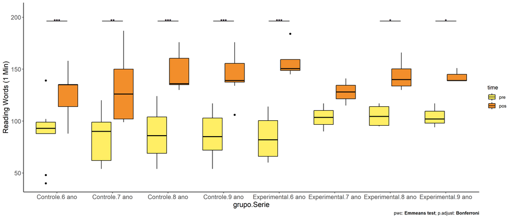

```r
if (length(unique(pdat[["Serie"]])) >= 2)
  plots[["grupo:Serie"]] + ggplot2::ylab("Reading Words (1 Min)") +
    if (ymin < ymax) ggplot2::ylim(ymin, ymax)
```

### Checking linearity assumption

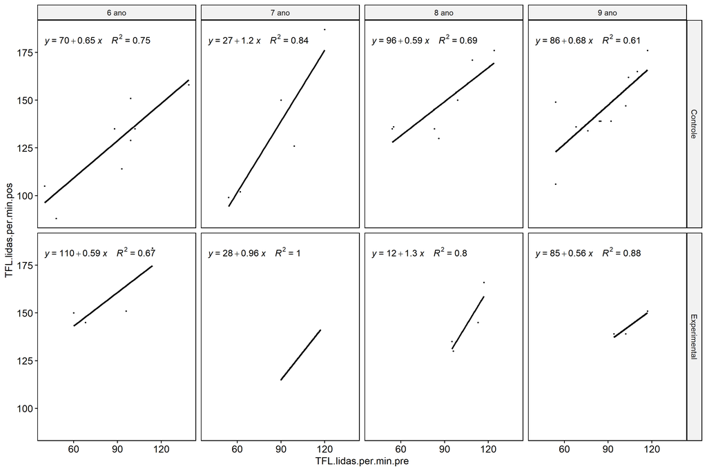

```r
if (length(unique(pdat[["Serie"]])) >= 2) {
  ggscatter(wdat, x = "TFL.lidas.per.min.pre", y = "TFL.lidas.per.min.pos", size = 0.5,
            facet.by = c("grupo","Serie"), add = "reg.line")+
    stat_regline_equation(
      aes(label =  paste(..eq.label.., ..rr.label.., sep = "~~~~"))
    ) +
    if (ymin < ymax) ggplot2::ylim(ymin, ymax)
}
```

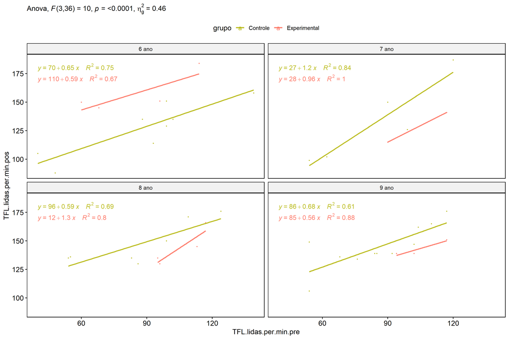

```r
if (length(unique(pdat[["Serie"]])) >= 2) {
  ggscatter(wdat, x = "TFL.lidas.per.min.pre", y = "TFL.lidas.per.min.pos", size = 0.5,
            color = "grupo", facet.by = "Serie", add = "reg.line")+
    stat_regline_equation(
      aes(label =  paste(..eq.label.., ..rr.label.., sep = "~~~~"), color = grupo)
    ) +
    ggplot2::labs(subtitle = rstatix::get_test_label(aov, detailed = T, row = which(aov$Effect == "grupo:Serie"))) +
    ggplot2::scale_color_manual(values = color[["grupo"]]) +
    if (ymin < ymax) ggplot2::ylim(ymin, ymax)
}
```

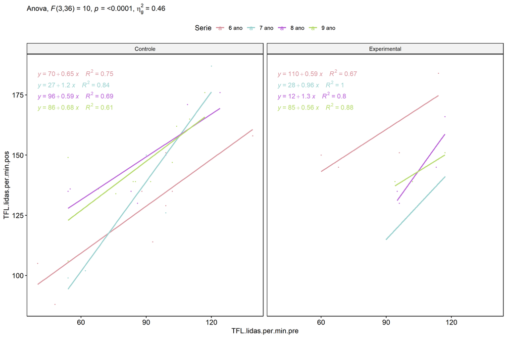

```r
if (length(unique(pdat[["Serie"]])) >= 2) {
  ggscatter(wdat, x = "TFL.lidas.per.min.pre", y = "TFL.lidas.per.min.pos", size = 0.5,
            color = "Serie", facet.by = "grupo", add = "reg.line")+
    stat_regline_equation(
      aes(label =  paste(..eq.label.., ..rr.label.., sep = "~~~~"), color = Serie)
    ) +
    ggplot2::labs(subtitle = rstatix::get_test_label(aov, detailed = T, row = which(aov$Effect == "grupo:Serie"))) +
    ggplot2::scale_color_manual(values = color[["Serie"]]) +
    if (ymin < ymax) ggplot2::ylim(ymin, ymax)
}
```

### Checking normality and homogeneity

```r
if (length(unique(pdat[["Serie"]])) >= 2)
  res <- augment(lm(TFL.lidas.per.min.pos ~ TFL.lidas.per.min.pre + grupo*Serie, data = wdat))
```

```r
if (length(unique(pdat[["Serie"]])) >= 2)
  shapiro_test(res$.resid)
```

```
## # A tibble: 1 × 3
##   variable   statistic p.value
##   <chr>          <dbl>   <dbl>
## 1 res$.resid     0.963   0.153
```

```r
if (length(unique(pdat[["Serie"]])) >= 2)
  levene_test(res, .resid ~ grupo*Serie)
```

```
## # A tibble: 1 × 4
##     df1   df2 statistic     p
##   <int> <int>     <dbl> <dbl>
## 1     7    37     0.819 0.578
```

# ANCOVA and Pairwise for two factors **grupo:TFL.lidas.per.min.quintile**

## Without remove non-normal data

```r
pdat = remove_group_data(dat[!is.na(dat[["grupo"]]) & !is.na(dat[["TFL.lidas.per.min.quintile"]]),],
                         "TFL.lidas.per.min.pos", c("grupo","TFL.lidas.per.min.quintile"))
pdat = pdat[pdat[["TFL.lidas.per.min.quintile"]] %in% do.call(
  intersect, lapply(unique(pdat[["grupo"]]), FUN = function(x) {
    unique(pdat[["TFL.lidas.per.min.quintile"]][which(pdat[["grupo"]] == x)])
  })),]
pdat[["grupo"]] = factor(pdat[["grupo"]], level[["grupo"]])
pdat[["TFL.lidas.per.min.quintile"]] = factor(
  pdat[["TFL.lidas.per.min.quintile"]],
  level[["TFL.lidas.per.min.quintile"]][level[["TFL.lidas.per.min.quintile"]] %in% unique(pdat[["TFL.lidas.per.min.quintile"]])])

pdat.long <- rbind(pdat[,c("id","grupo","TFL.lidas.per.min.quintile")], pdat[,c("id","grupo","TFL.lidas.per.min.quintile")])
pdat.long[["time"]] <- c(rep("pre", nrow(pdat)), rep("pos", nrow(pdat)))
pdat.long[["time"]] <- factor(pdat.long[["time"]], c("pre","pos"))
pdat.long[["TFL.lidas.per.min"]] <- c(pdat[["TFL.lidas.per.min.pre"]], pdat[["TFL.lidas.per.min.pos"]])

if (length(unique(pdat[["TFL.lidas.per.min.quintile"]])) >= 2) {
  aov = anova_test(pdat, TFL.lidas.per.min.pos ~ TFL.lidas.per.min.pre + grupo*TFL.lidas.per.min.quintile)
  laov[["grupo:TFL.lidas.per.min.quintile"]] <- get_anova_table(aov)
}
```

```r
if (length(unique(pdat[["TFL.lidas.per.min.quintile"]])) >= 2) {
  pwcs <- list()
  pwcs[["TFL.lidas.per.min.quintile"]] <- emmeans_test(
    group_by(pdat, grupo), TFL.lidas.per.min.pos ~ TFL.lidas.per.min.quintile,
    covariate = TFL.lidas.per.min.pre, p.adjust.method = "bonferroni")
  pwcs[["grupo"]] <- emmeans_test(
    group_by(pdat, TFL.lidas.per.min.quintile), TFL.lidas.per.min.pos ~ grupo,
    covariate = TFL.lidas.per.min.pre, p.adjust.method = "bonferroni")

  pwc <- plyr::rbind.fill(pwcs[["grupo"]], pwcs[["TFL.lidas.per.min.quintile"]])
  pwc <- pwc[,c("grupo","TFL.lidas.per.min.quintile", colnames(pwc)[!colnames(pwc) %in% c("grupo","TFL.lidas.per.min.quintile")])]
}
```

```r
if (length(unique(pdat[["TFL.lidas.per.min.quintile"]])) >= 2) {
  pwc.long <- emmeans_test(dplyr::group_by_at(pdat.long, c("grupo","TFL.lidas.per.min.quintile")),
                           TFL.lidas.per.min ~ time,
                           p.adjust.method = "bonferroni")
  lpwc[["grupo:TFL.lidas.per.min.quintile"]] <- plyr::rbind.fill(pwc, pwc.long)
}
```

```r
if (length(unique(pdat[["TFL.lidas.per.min.quintile"]])) >= 2) {
  ds <- get.descriptives(pdat, "TFL.lidas.per.min.pos", c("grupo","TFL.lidas.per.min.quintile"), covar = "TFL.lidas.per.min.pre")
  ds <- merge(ds[ds$variable != "TFL.lidas.per.min.pre",],
              ds[ds$variable == "TFL.lidas.per.min.pre", !colnames(ds) %in% c("variable")],
              by = c("grupo","TFL.lidas.per.min.quintile"), all.x = T, suffixes = c("", ".TFL.lidas.per.min.pre"))
  ds <- merge(get_emmeans(pwcs[["grupo"]]), ds,
              by = c("grupo","TFL.lidas.per.min.quintile"), suffixes = c(".emms", ""))
  ds <- ds[,c("grupo","TFL.lidas.per.min.quintile","n","mean.TFL.lidas.per.min.pre","se.TFL.lidas.per.min.pre","mean","se",
              "emmean","se.emms","conf.low","conf.high")]

  colnames(ds) <- c("grupo","TFL.lidas.per.min.quintile", "N", paste0(c("M","SE")," (pre)"),
                    paste0(c("M","SE"), " (unadj)"),
                    paste0(c("M", "SE"), " (adj)"), "conf.low", "conf.high")

  lemms[["grupo:TFL.lidas.per.min.quintile"]] <- ds
}
```

## Computing ANCOVA and PairWise After removing non-normal data (OK)

```r
if (length(unique(pdat[["TFL.lidas.per.min.quintile"]])) >= 2) {
  wdat = pdat

  res = residuals(lm(TFL.lidas.per.min.pos ~ TFL.lidas.per.min.pre + grupo*TFL.lidas.per.min.quintile, data = wdat))
  non.normal = getNonNormal(res, wdat$id, plimit = 0.05)

  wdat = wdat[!wdat$id %in% non.normal,]

  wdat.long <- rbind(wdat[,c("id","grupo","TFL.lidas.per.min.quintile")], wdat[,c("id","grupo","TFL.lidas.per.min.quintile")])
  wdat.long[["time"]] <- c(rep("pre", nrow(wdat)), rep("pos", nrow(wdat)))
  wdat.long[["time"]] <- factor(wdat.long[["time"]], c("pre","pos"))
  wdat.long[["TFL.lidas.per.min"]] <- c(wdat[["TFL.lidas.per.min.pre"]], wdat[["TFL.lidas.per.min.pos"]])


  ldat[["grupo:TFL.lidas.per.min.quintile"]] = wdat

  (non.normal)
}
```

```
##  [1] "P808"  "P463"  "P3516" "P956"  "P3504" "P3721" "P1109" "P820"  "P1010" "P3492" "P3581"
## [12] "P1091" "P3609" "P3627" "P1094" "P3501" "P3729" "P3566" "P3498" "P3521" "P445"  "P1097"
## [23] "P521"  "P446"  "P3502" "P812"  "P1000" "P816"  "P465"  "P621"  "P947"  "P3606" "P942"
## [34] "P3495" "P618"  "P628"  "P950"  "P241"  "P451"  "P515"  "P448"  "P3558" "P3505" "P128"
## [45] "P1017" "P1089" "P3518" "P615"  "P994"  "P1084" "P813"  "P626"  "P460"  "P3512" "P3524"
## [56] "P184"  "P133"  "P616"  "P1716" "P936"  "P513"  "P3615" "P464"  "P512"  "P3519" "P620"
## [67] "P3565" "P2210" "P3560" "P176"  "P523"  "P3734" "P614"  "P3577" "P457"  "P943"  "P3509"
## [78] "P613"  "P3598" "P997"  "P3624" "P1729" "P1004" "P516"  "P1742" "P829"  "P612"  "P948"
## [89] "P1107" "P625"  "P449"  "P3578" "P941"  "P953"  "P958"  "P3569" "P174"
```

```r
if (length(unique(pdat[["TFL.lidas.per.min.quintile"]])) >= 2) {
  aov = anova_test(wdat, TFL.lidas.per.min.pos ~ TFL.lidas.per.min.pre + grupo*TFL.lidas.per.min.quintile)
  laov[["grupo:TFL.lidas.per.min.quintile"]] <- merge(get_anova_table(aov), laov[["grupo:TFL.lidas.per.min.quintile"]],
                                         by="Effect", suffixes = c("","'"))
  df = get_anova_table(aov)
}
```

| Effect | DFn | DFd | F | p | p<.05 | ges |
| --- | --- | --- | --- | --- | --- | --- |
| TFL.lidas.per.min.pre | 1 | 36 | 3.613 | 0.065 |  | 0.091 |
| grupo | 1 | 36 | 0.022 | 0.882 |  | 0.001 |
| TFL.lidas.per.min.quintile | 4 | 36 | 2.148 | 0.095 |  | 0.193 |
| grupo:TFL.lidas.per.min.quintile | 4 | 36 | 0.705 | 0.594 |  | 0.073 |

```r
if (length(unique(pdat[["TFL.lidas.per.min.quintile"]])) >= 2) {
  pwcs <- list()
  pwcs[["TFL.lidas.per.min.quintile"]] <- emmeans_test(
    group_by(wdat, grupo), TFL.lidas.per.min.pos ~ TFL.lidas.per.min.quintile,
    covariate = TFL.lidas.per.min.pre, p.adjust.method = "bonferroni")
  pwcs[["grupo"]] <- emmeans_test(
    group_by(wdat, TFL.lidas.per.min.quintile), TFL.lidas.per.min.pos ~ grupo,
    covariate = TFL.lidas.per.min.pre, p.adjust.method = "bonferroni")

  pwc <- plyr::rbind.fill(pwcs[["grupo"]], pwcs[["TFL.lidas.per.min.quintile"]])
  pwc <- pwc[,c("grupo","TFL.lidas.per.min.quintile", colnames(pwc)[!colnames(pwc) %in% c("grupo","TFL.lidas.per.min.quintile")])]
}
```

| grupo | TFL.lidas.per.min.quintile | term | .y. | group1 | group2 | df | statistic | p | p.adj | p.adj.signif |
| --- | --- | --- | --- | --- | --- | --- | --- | --- | --- | --- |
|  | 1st quintile | TFL.lidas.per.min.pre*grupo | TFL.lidas.per.min.pos | Controle | Experimental | 36 | -1.106 | 0.276 | 0.276 | ns |
|  | 2nd quintile | TFL.lidas.per.min.pre*grupo | TFL.lidas.per.min.pos | Controle | Experimental | 36 | -0.061 | 0.951 | 0.951 | ns |
|  | 3rd quintile | TFL.lidas.per.min.pre*grupo | TFL.lidas.per.min.pos | Controle | Experimental | 36 | 1.131 | 0.265 | 0.265 | ns |
|  | 4th quintile | TFL.lidas.per.min.pre*grupo | TFL.lidas.per.min.pos | Controle | Experimental | 36 | -0.433 | 0.667 | 0.667 | ns |
|  | 5th quintile | TFL.lidas.per.min.pre*grupo | TFL.lidas.per.min.pos | Controle | Experimental | 36 | -0.251 | 0.804 | 0.804 | ns |
| Controle |  | TFL.lidas.per.min.pre*TFL.lidas.per.min.quintile | TFL.lidas.per.min.pos | 1st quintile | 2nd quintile | 36 | 0.882 | 0.383 | 1.000 | ns |
| Controle |  | TFL.lidas.per.min.pre*TFL.lidas.per.min.quintile | TFL.lidas.per.min.pos | 1st quintile | 3rd quintile | 36 | 1.102 | 0.278 | 1.000 | ns |
| Controle |  | TFL.lidas.per.min.pre*TFL.lidas.per.min.quintile | TFL.lidas.per.min.pos | 1st quintile | 4th quintile | 36 | 0.725 | 0.473 | 1.000 | ns |
| Controle |  | TFL.lidas.per.min.pre*TFL.lidas.per.min.quintile | TFL.lidas.per.min.pos | 1st quintile | 5th quintile | 36 | 0.649 | 0.520 | 1.000 | ns |
| Controle |  | TFL.lidas.per.min.pre*TFL.lidas.per.min.quintile | TFL.lidas.per.min.pos | 2nd quintile | 3rd quintile | 36 | 0.823 | 0.416 | 1.000 | ns |
| Controle |  | TFL.lidas.per.min.pre*TFL.lidas.per.min.quintile | TFL.lidas.per.min.pos | 2nd quintile | 4th quintile | 36 | 0.332 | 0.742 | 1.000 | ns |
| Controle |  | TFL.lidas.per.min.pre*TFL.lidas.per.min.quintile | TFL.lidas.per.min.pos | 2nd quintile | 5th quintile | 36 | 0.390 | 0.699 | 1.000 | ns |
| Controle |  | TFL.lidas.per.min.pre*TFL.lidas.per.min.quintile | TFL.lidas.per.min.pos | 3rd quintile | 4th quintile | 36 | -0.368 | 0.715 | 1.000 | ns |
| Controle |  | TFL.lidas.per.min.pre*TFL.lidas.per.min.quintile | TFL.lidas.per.min.pos | 3rd quintile | 5th quintile | 36 | 0.019 | 0.985 | 1.000 | ns |
| Controle |  | TFL.lidas.per.min.pre*TFL.lidas.per.min.quintile | TFL.lidas.per.min.pos | 4th quintile | 5th quintile | 36 | 0.326 | 0.746 | 1.000 | ns |
| Experimental |  | TFL.lidas.per.min.pre*TFL.lidas.per.min.quintile | TFL.lidas.per.min.pos | 1st quintile | 2nd quintile | 36 | 1.671 | 0.103 | 1.000 | ns |
| Experimental |  | TFL.lidas.per.min.pre*TFL.lidas.per.min.quintile | TFL.lidas.per.min.pos | 1st quintile | 3rd quintile | 36 | 2.320 | 0.026 | 0.261 | ns |
| Experimental |  | TFL.lidas.per.min.pre*TFL.lidas.per.min.quintile | TFL.lidas.per.min.pos | 1st quintile | 4th quintile | 36 | 1.286 | 0.207 | 1.000 | ns |
| Experimental |  | TFL.lidas.per.min.pre*TFL.lidas.per.min.quintile | TFL.lidas.per.min.pos | 1st quintile | 5th quintile | 36 | 1.245 | 0.221 | 1.000 | ns |
| Experimental |  | TFL.lidas.per.min.pre*TFL.lidas.per.min.quintile | TFL.lidas.per.min.pos | 2nd quintile | 3rd quintile | 36 | 1.184 | 0.244 | 1.000 | ns |
| Experimental |  | TFL.lidas.per.min.pre*TFL.lidas.per.min.quintile | TFL.lidas.per.min.pos | 2nd quintile | 4th quintile | 36 | 0.056 | 0.956 | 1.000 | ns |
| Experimental |  | TFL.lidas.per.min.pre*TFL.lidas.per.min.quintile | TFL.lidas.per.min.pos | 2nd quintile | 5th quintile | 36 | 0.260 | 0.796 | 1.000 | ns |
| Experimental |  | TFL.lidas.per.min.pre*TFL.lidas.per.min.quintile | TFL.lidas.per.min.pos | 3rd quintile | 4th quintile | 36 | -1.703 | 0.097 | 0.972 | ns |
| Experimental |  | TFL.lidas.per.min.pre*TFL.lidas.per.min.quintile | TFL.lidas.per.min.pos | 3rd quintile | 5th quintile | 36 | -0.890 | 0.379 | 1.000 | ns |
| Experimental |  | TFL.lidas.per.min.pre*TFL.lidas.per.min.quintile | TFL.lidas.per.min.pos | 4th quintile | 5th quintile | 36 | 0.438 | 0.664 | 1.000 | ns |

```r
if (length(unique(pdat[["TFL.lidas.per.min.quintile"]])) >= 2) {
  pwc.long <- emmeans_test(dplyr::group_by_at(wdat.long, c("grupo","TFL.lidas.per.min.quintile")),
                           TFL.lidas.per.min ~ time,
                           p.adjust.method = "bonferroni")
  lpwc[["grupo:TFL.lidas.per.min.quintile"]] <- merge(plyr::rbind.fill(pwc, pwc.long),
                                         lpwc[["grupo:TFL.lidas.per.min.quintile"]],
                                         by=c("grupo","TFL.lidas.per.min.quintile","term",".y.","group1","group2"),
                                         suffixes = c("","'"))
}
```

| grupo | TFL.lidas.per.min.quintile | term | .y. | group1 | group2 | df | statistic | p | p.adj | p.adj.signif |
| --- | --- | --- | --- | --- | --- | --- | --- | --- | --- | --- |
| Controle | 1st quintile | time | TFL.lidas.per.min | pre | pos | 74 | -9.478 | 0 | 0 | **** |
| Controle | 2nd quintile | time | TFL.lidas.per.min | pre | pos | 74 | -7.875 | 0 | 0 | **** |
| Controle | 3rd quintile | time | TFL.lidas.per.min | pre | pos | 74 | -5.501 | 0 | 0 | **** |
| Controle | 4th quintile | time | TFL.lidas.per.min | pre | pos | 74 | -7.562 | 0 | 0 | **** |
| Controle | 5th quintile | time | TFL.lidas.per.min | pre | pos | 74 | -5.328 | 0 | 0 | **** |
| Experimental | 1st quintile | time | TFL.lidas.per.min | pre | pos | 74 | -4.987 | 0 | 0 | **** |
| Experimental | 2nd quintile | time | TFL.lidas.per.min | pre | pos | 74 | -4.310 | 0 | 0 | **** |
| Experimental | 3rd quintile | time | TFL.lidas.per.min | pre | pos | 74 | -4.014 | 0 | 0 | *** |
| Experimental | 4th quintile | time | TFL.lidas.per.min | pre | pos | 74 | -5.846 | 0 | 0 | **** |
| Experimental | 5th quintile | time | TFL.lidas.per.min | pre | pos | 74 | -5.125 | 0 | 0 | **** |

```r
if (length(unique(pdat[["TFL.lidas.per.min.quintile"]])) >= 2) {
  ds <- get.descriptives(wdat, "TFL.lidas.per.min.pos", c("grupo","TFL.lidas.per.min.quintile"), covar = "TFL.lidas.per.min.pre")
  ds <- merge(ds[ds$variable != "TFL.lidas.per.min.pre",],
              ds[ds$variable == "TFL.lidas.per.min.pre", !colnames(ds) %in% c("variable")],
              by = c("grupo","TFL.lidas.per.min.quintile"), all.x = T, suffixes = c("", ".TFL.lidas.per.min.pre"))
  ds <- merge(get_emmeans(pwcs[["grupo"]]), ds,
              by = c("grupo","TFL.lidas.per.min.quintile"), suffixes = c(".emms", ""))
  ds <- ds[,c("grupo","TFL.lidas.per.min.quintile","n","mean.TFL.lidas.per.min.pre","se.TFL.lidas.per.min.pre",
              "mean","se","emmean","se.emms","conf.low","conf.high")]

  colnames(ds) <- c("grupo","TFL.lidas.per.min.quintile", "N", paste0(c("M","SE")," (pre)"),
                    paste0(c("M","SE"), " (unadj)"),
                    paste0(c("M", "SE"), " (adj)"), "conf.low", "conf.high")

  lemms[["grupo:TFL.lidas.per.min.quintile"]] <- merge(ds, lemms[["grupo:TFL.lidas.per.min.quintile"]],
                                          by=c("grupo","TFL.lidas.per.min.quintile"), suffixes = c("","'"))
}
```

| grupo | TFL.lidas.per.min.quintile | N | M (pre) | SE (pre) | M (unadj) | SE (unadj) | M (adj) | SE (adj) | conf.low | conf.high |
| --- | --- | --- | --- | --- | --- | --- | --- | --- | --- | --- |
| Controle | 1st quintile | 6 | 51.833 | 2.372 | 121.667 | 8.500 | 159.843 | 21.203 | 116.842 | 202.845 |
| Controle | 2nd quintile | 7 | 80.429 | 2.419 | 134.143 | 1.792 | 144.598 | 8.358 | 127.646 | 161.549 |
| Controle | 3rd quintile | 5 | 90.200 | 1.020 | 134.600 | 5.836 | 135.582 | 7.465 | 120.442 | 150.722 |
| Controle | 4th quintile | 8 | 103.000 | 1.558 | 151.250 | 5.130 | 139.823 | 8.414 | 122.758 | 156.888 |
| Controle | 5th quintile | 5 | 123.600 | 4.032 | 166.600 | 8.953 | 135.202 | 18.119 | 98.455 | 171.949 |
| Experimental | 1st quintile | 1 | 60.000 |  | 150.000 |  | 180.260 | 23.037 | 133.538 | 226.981 |
| Experimental | 2nd quintile | 2 | 68.000 | 0.000 | 123.000 | 22.000 | 145.504 | 16.697 | 111.640 | 179.368 |
| Experimental | 3rd quintile | 5 | 91.800 | 1.114 | 124.200 | 5.276 | 123.631 | 7.453 | 108.515 | 138.746 |
| Experimental | 4th quintile | 4 | 101.000 | 3.317 | 153.750 | 14.407 | 144.262 | 9.708 | 124.574 | 163.950 |
| Experimental | 5th quintile | 4 | 115.250 | 1.031 | 161.500 | 8.703 | 138.197 | 14.819 | 108.142 | 168.252 |